[figure not shown]

# Rozhodovací procesy

Zájem obcí a krajů spravovat své záležitosti otevřeně před občany, jinými slovy ztransparentnit samosprávu, závisí částečně na zákonech, ale výrazně také na vůli jejího vedení. Chtějí-li tedy političtí představitelé politiku transparentnosti realizovat, musí příkladně začít u sebe, tj. otevřením rozhodování zastupitelstva a rady. Každý [občan obce má ze zákona právo](https://www.zakonyprolidi.cz/cs/2000-128/zneni-20160701#p16) se na své zastupitele obracet v obecních záležitostech a [být přítomen zasedání zastupitelstva](https://www.zakonyprolidi.cz/cs/2000-128/zneni-20160701#p16-2-c). Aby těchto práv mohl plně využívat, musí mít dobrý přístup k informacím ze zastupitelstva, rady a obecního úřadu.

### Rozhodovací procesy

Obce (ale ekvivalentně i kraje a hlavní město Praha) jsou územními korporacemi, kterým Ústava ČR garantuje právo na samosprávu. Zároveň jim lze na základě zákona svěřit výkon státní správy (přenesené působnosti). Aby mohl jednak odpovědně spravovat své vlastní záležitosti a jednak vykonávat svěřenou státní správu, zřizuje si územní celek orgány. Zákony, které určují orgány obce, kraje, hlavního města Prahy a jeho městských částí a zároveň vymezují jejich působnost, jsou: [zákon č. 128/2000 Sb., o obcích](https://www.zakonyprolidi.cz/cs/2000-128) (obecní zřízení; dále jen „ZOZ“), [zákon č. 129/2000 Sb., o krajích](https://www.zakonyprolidi.cz/cs/2000-129), (krajské zřízení, dále jen „ZKZ“) a [zákon č. 131/2000 Sb., o hlavním městě Praze](https://www.zakonyprolidi.cz/cs/2000-131), (dále jen „ZPZ“).

Územní celek má podle ustanovení [§ 5 odst. 1 ZOZ](https://www.zakonyprolidi.cz/cs/2000-128/zneni-20160701#p5-1), [§ 1 odst. 3 ZKZ](https://www.zakonyprolidi.cz/cs/2000-129/zneni-20160701#p1-3) a [§ 1 odst. 4](https://www.zakonyprolidi.cz/cs/2000-131/zneni-20160701#p1-4) a [§ 4 odst. 1 ZPZ](https://www.zakonyprolidi.cz/cs/2000-131/zneni-20160701#p4-1)čtyři základní orgány:

- Zastupitelstvo obce / kraje / městské části / hlavního města Prahy
- Rada obce / kraje / městské části (dále jen MČ) / hlavního města Prahy
- Starosta obce / hejtman kraje / starosta MČ / primátor hlavního města Prahy
- Obecní úřad / krajský úřad / úřad MČ / magistrát hlavního města Prahy.

Pro zjednodušení je nadále v textu užíván termín obec, zastupitelstvo obce, rada obce, starosta obce, obecní úřad atd., avšak obdobně níže uvedené informace platí i pro ostatní územně samosprávné celky.

Nejvyšším orgánem, voleným přímo občany obce, je **zastupitelstvo** obce, které ze svých členů volí **starostu** a **radu** obce. **Obecní úřad** zejména zajišťuje výkon rozhodnutí jiných orgánů obce a dále provádí výkon přenesené státní správy. Pro všechny orgány obce je charakteristické, že jsou nadány určitou rozhodovací pravomocí, a to v míře, kterou jim stanoví zákon, nebo v míře, kterou si v mezích zákona navzájem udělují či odjímají. Zastupitelstvo obce i rada obce si navíc zřizují ke své činnosti **pomocné orgány** (**výbory a komise**). Výborům zastupitelstva obce ani komisím rady obce ze zákona svěřena rozhodovací pravomoc není, nicméně v praxi bývá jejich vliv na rozhodnutí zastupitelstva či rady poměrně zásadní.

Vzhledem k tomu, že obce prostřednictvím svých orgánů vykonávají v širším slova smyslu veřejnou správu a je jim svěřen široký okruh pravomocí, je třeba zajistit účinné mechanismy kontroly jejich činnosti, mezi nimiž zaujímá zvláštní místo kontrola ze strany veřejnosti. Aktivní účast občanů na správě věcí veřejných může fungovat jako významný kontrolní mechanismus a garant transparentního a efektivního výkonu samosprávy. Tato kontrola ovšem vyžaduje porozumění tomu, o jakých otázkách jednotlivé orgány obce rozhodují a jakou procedurou přijímají svá rozhodnutí, jakým způsobem je možné ovlivňovat tento rozhodovací proces a tím z pozice občana participovat na výkonu samosprávy.

#### 1) Zastupitelstvo obce a jeho pravomoci

**Občan obce má rovněž právo na projednání určité záležitosti** spadající do samostatné působnosti takřka podle svého přání. Podle [§ 16 odst. 2 písm f) ZOZ](https://www.zakonyprolidi.cz/cs/2000-128/zneni-20160701#p16-2-f) je třeba odlišovat žádosti tzv. “prosté” a “kvalifikované” – tzn. ty, které jsou podepsány 0,5 % občanů. Ministerstvo vnitra dovodilo, že i v případě “prosté” žádosti by měly být požadované žádosti být projednány do 60ti dní, pokud spadají do působnosti rady obce, a do 90 dnů, pokud spadají do působnosti zastupitelstva. Více viz [stanovisko č. 1/2015](http://www.mvcr.cz/odk2/clanek/stanoviska-odk-2015.aspx).

U **obcí, ve kterých není zřízena rada** obce, se kompetence rady rozdělují mezi starostu a zastupitelstvo obce. Dle [stanoviska Ministerstva vnitra č. 2/2013](http://www.mvcr.cz/odk2/clanek/stanoviska-odk-2013.aspx) (se kterým se částečně ztotožňujeme) není možné hledět na starostu jako na orgán obce, který “stává” radou obce. Zastupitelstvo si tedy smí ve svůj prospěch vyhradit i záležitosti, které by jinak spadaly do vyhrazených pravomocí rady. [§ 84 odst. 4 ZOZ](https://www.zakonyprolidi.cz/cs/2000-128/zneni-20160701#p84-4) se tak neuplatní a zastupitelstvo si na sebe může “vztáhnout” i další kompetence mimo “zbytkové” pravomoci rady podle [§ 102 odst. 3 ZOZ](https://www.zakonyprolidi.cz/cs/2000-128/zneni-20160701#p102-3).

#### i) Co je to uvolněný / neuvolněný člen zastupitelstva obce, jaká jim přísluší odměna? Mohou obdržet dary od obce?

Mezi vyhrazené pravomoci zastupitelstva obce náleží i rozhodování o tom, [pro které funkce a kteří z členů zastupitelstva obce budou pro výkon své funkce dlouhodobě uvolněni](https://www.zakonyprolidi.cz/cs/2000-128/zneni-20160701#p84-2-k).

**Uvolněným zastupitelem** se rozumí osoba, která vykonává volenou funkci na *„plný úvazek“* a tedy za tomu odpovídající odměnu. Uvolněný zastupitel je dlouhodobě **uvolněn z pracovního poměru** a fakticky se stává po dobu výkonu své funkce „jakoby“ zaměstnancem obce. Odměna se v takovém případě vyplácí i těm, kteří před zvolením do funkce nebyli výdělečně činní (např. důchodci). Zpravidla bývá uvolněným zastupitelem starosta, někteří radní, občas předseda Kontrolního výboru nebo předseda Finančního výboru. **Od 1.1.2018** pak pravidla pro odměňování zastupitelů obcí krajů i hlavního města Prahy **budou nově přímo součástí příslušných zákonů**, kterou provádí [zákon č. 99/2017 Sb.](https://www.zakonyprolidi.cz/cs/2017-99/zneni-20180101#Top)

Obligatorně se odměna vyplácí z rozpočtových prostředků samosprávy pouze uvolněným zastupitelům. Neuvolněným zastupitelům může být (ale nemusí) za výkon funkce poskytnuta rovněž měsíční odměna, přičemž její maximální výši stanoví citované nařízení.Od roku 2018 to ale bude jinak a zastupitelé si obecně finančně polepší.

Zatímco uvolněný člen zastupitelstva má právní nárok na odměnu za výkon své funkce, neuvolněný člen zastupitelstva nikoliv. Pokud jsou neuvolnění zastupitelé v pracovním poměru, je jejich zaměstnavatel povinen jim za účelem výkonu funkce zastupitele poskytnout pracovní volno s náhradou mzdy v rozsahu doby potřebné pro výkon funkce. Potřebný rozsah určuje obec, v každém případě se jedná minimálně o poskytnutí pracovního volna pro možnost účasti na zasedání zastupitelstva. Náhradu vyplacené mzdy uhradí zaměstnavateli obec. Neuvolněným zastupitelům, kteří nejsou v pracovním poměru, poskytuje obec náhradu ušlého výdělku za dobu strávenou výkonem funkce paušální částkou, jejíž výši stanoví zastupitelstvo. Paušální částka není součástí odměny a poskytuje se rovněž i důchodcům, matkám na mateřské dovolené, osobám v domácnosti apod.

**Dary zastupitelům**

Od roku 2018 je možné **obdarovat člena zastupitelstva za splnění “mimořádných nebo zvláště významných úkolů”, které souviseli s jeho funkcí**. Tyto dary mají nově specifikovaná pravidla, jelikož praxe před rokem 2018 byla často velice rozvolněná, když si dary rozdávali radní a bez jakéhokoli dohledatelného odůvodnění. Dary zastupitelům bude muset projednávat zastupitelstvo v separátním bodu jednání a usnesení o udělení daru musí být explicitně odůvodněno.I výše takových darů je nově omezena jak měsíční, tak roční výší. Zastupitel si tak za rok může přijít nejvýše na dvojnásobek své maximální měsíční odměny. Toto platí jak pro uvolněné tak pro neuvolněné zastupitele.

**Jiné dary** od obce by musel zastupitel obdržet pouze za činnosti, **které nesouvisejí s výkonem jeho funkce zastupitele** (např. jakožto trenérovi či sportovci za jeho mimořádné úspěchy), jinak by takový dar bylo třeba považovat za bezdůvodné obohacení.

#### ii) Kdy se koná zasedání zastupitelstva obce? A kdy by se mělo konat?

Zastupitelstvo obce se schází **podle potřeby**, nejméně však jedenkrát za tři měsíce. Zastupitelstvo zpravidla svolává a řídí starosta obce ([§ 92 ZOZ](https://www.zakonyprolidi.cz/cs/2000-128/zneni-20160701#p92)), resp. hejtman kraje ([§ 40 ZKZ](https://www.zakonyprolidi.cz/cs/2000-129/zneni-20160701#p40)), resp. primátor hlavního města Prahy, a to písemně se sdělením navrženého programu jednání ([§ 60 ZPZ](https://www.zakonyprolidi.cz/cs/2000-131/zneni-20160701#f2028559)). Tito jsou povinni svolat zasedání zastupitelstva také tehdy, **požádá-li o to alespoň jedna třetina zastupitelů** ([§ 41 odst. 2 ZKZ](https://www.zakonyprolidi.cz/cs/2000-129/zneni-20160701#p41-2) a [§ 60 odst. 2 ZPZ](https://www.zakonyprolidi.cz/cs/2000-131/zneni-20160701#p60-2)), nebo v případě obcí též hejtman kraje ([§ 92 odst. 1 ZOZ](https://www.zakonyprolidi.cz/cs/2000-128/zneni-20160701#p92-1)). Zasedání se přitom koná nejpozději do 21 dnů ode dne doručení žádosti obecnímu úřadu, resp. do 15 dnů ode dne doručení Magistrátu hlavního města Prahy. Jestliže starosta zasedání nesvolá, svolá jej místostarosta, popřípadě jiný člen zastupitelstva obce.

**Kde zastupitelstvo zasedá?**

Zastupitelstva obce se mohou konat pouze v jejich územním obvodu. “Výjezdní” zasedání tedy nepřipadají v úvahu. O místě konání krajského zastupitelstva resp. zast. hl. města Prahy informuje krajský úřad, resp. Magistrát hl. města Prahy.Zákon již ale blíže nespecifikuje, kde přesně se jejich zastupitelstva musí sejít. “Výjezdní” zasedání krajského zastupitelstva nebo Zastupitelstva hl. města Prahy tak v zásadě do úvahy přicházejí.

#### iii) Kdy je zastupitelstvo obce usnášeníschopné?

Zastupitelstvo obce je schopno se usnášet, je-li přítomna **nadpoloviční většina všech jeho členů**. V případě, že při zahájení jednání zastupitelstva nebo v jeho průběhu není přítomna nadpoloviční většina všech jeho členů, ukončí předsedající zasedání s tím, že do 15 dnů se musí konat náhradní zasedání. K platnému usnesení zastupitelstva, rozhodnutí nebo volbě je totiž třeba podle ustanovení [§ 87 ZOZ](https://www.zakonyprolidi.cz/cs/2000-128/zneni-20160701#p87-1), [§ 40 odst. 2 ZKZ](https://www.zakonyprolidi.cz/cs/2000-129/zneni-20160701#p40-2) a [§ 62 ZPZ](https://www.zakonyprolidi.cz/cs/2000-131/zneni-20160701#p62-1) souhlasu nadpoloviční většiny všech členů zastupitelstva.

#### iv) Jak se dozvím, kdy se koná zasedání zastupitelstva obce?

O době, místě a navrženém programu připravovaného zasedání zastupitelstva obce informuje obecní úřad na své úřední desce, a to nejméně 7 dní před jeho konáním (viz [§ 93 odst. 1 ZOZ](https://www.zakonyprolidi.cz/cs/2000-128/zneni-20160701#p93-1) a [§ 60 odst. 3 ZPZ](https://www.zakonyprolidi.cz/cs/2000-131/zneni-20160701#p60-3)), resp. nejméně 10 dnů před jeho konáním (viz [§ 42 odst.1 ZKZ](https://www.zakonyprolidi.cz/cs/2000-129/zneni-20160701#p42-1)). V praxi toto zákonné ustanovení bohužel znamená, že se dříve než jeden týden (deset dní) předem o konání zasedání zastupitelstva nedozvíte, a to ani jako občan a často ani jako opoziční zastupitel. Úřední deska musí být ze zákona nepřetržitě veřejně přístupná, tedy i v nočních hodinách. Její obsah se zveřejňuje též způsobem umožňujícím dálkový přístup (zpravidla prostřednictvím internetu). Kromě toho může obec informaci o plánovaném zasedání zastupitelstva obce uveřejnit způsobem v místě obvyklým (např. na jiné informační tabuli, dnes už i např. na sociálních sítích nebo v radničním periodiku). Jestliže obec nesplní povinnost informovat občany o připravovaném zasedání zastupitelstva obce popsaným způsobem, pak nelze hovořit o splnění zákonem stanoveného požadavku veřejnosti zasedání zastupitelstva obce. Takové zasedání nelze považovat za řádné zasedání tohoto orgánu a usnesení na něm přijatá za právně relevantní rozhodnutí zastupitelstva obce.

**Plán zasedání**

Každé zastupitelstvo by mělo připravovat a zveřejňovat dlouhodobější harmonogram zasedání. Takový plán není jen vhodnou pomůckou pro veřejnost. Snad ještě zásadnější roli má pro neuvolněné zastupitele. Pokud ti nemají k dispozici dostatečně dlouho předem informaci o tom, kdy se jednání koná, mají vážné problémy se sladěním harmonogramu svého zaměstnání a práce zastupitele. Zaměstnavatel má sice ze zákona povinnost poskytnout zastupiteli na zasedání pracovní volno, nicméně pokud si již zastupitel v zaměstnání například naplánoval zahraniční pracovní cestu, plány se mění opravdu již velmi obtížně. Nejvhodnější proto je zveřejňovat plány jednání na celý rok dopředu a to již s jistým předstihem před koncem roku. Schvalování takového plánu je velmi běžné na malých i velkých samosprávách, nicméně bohužel zdaleka ne ve všech případech samospráva plán zveřejní i pro potřebu občanů.

**Kdy by se mělo konat zasedání zastupitelstva?**

Zastupitelstvo se schází “podle potřeby”, což by mělo reflektovat i konkrétní situace.Termín zasedání zastupitelstva samozřejmě může velice ovlivnit přítomnost jak veřejnosti, tak samotných zastupitelů. Starosta má tedy v rukou nástroj, jak se případně vyhnout konfrontaci např. s bouřlivým davem, který dopředu nesouhlasí s chystaným rozhodnutím zastupitelstva. Pokud se na středně velkém městě chystá sporná výstavba v centru města a starosta svolá zastupitelstvo na dopoledne v pracovní den či první den letních prázdnin, pak si může být jistý, že přítomnost na zastupitelstvu příliš vysoká nebude. Naopak obec v chatové oblasti by měla zvážit, zda nesvolat zasedání spíše na víkend, kdy je v obci fakticky více zainteresovaných lidí.

#### v) Mají obce podrobnosti o jednání zastupitelstva obce upraveny v nějakém řádu?

V ustanovení [§ 96 ZOZ](https://www.zakonyprolidi.cz/cs/2000-128/zneni-20160701#p96), [§ 44 ZKZ](https://www.zakonyprolidi.cz/cs/2000-129/zneni-20160701#p44) a [§ 66 ZPZ](https://www.zakonyprolidi.cz/cs/2000-131/zneni-20160701#p66) je zastupitelstvu uložena povinnost vydat jednací řád, v němž stanoví podrobnosti o jednání zastupitelstva. V případě jednacího řádu zastupitelstva kraje je navíc stanoveno, aby jeho obsahem byla i podrobnější úprava jednání výborů, a v případě jednacího řádu Zastupitelstva hlavního města Prahy též postup při projednávání návrhů zákonů podávaných Poslanecké sněmovně. Jednací řád se zpravidla přijímá usnesením zastupitelstva obce. Má formu interního předpisu, nejedná se tedy o obecný právní předpis, jehož porušení by bylo zákonem sankcionováno. Vynutitelné jsou pochopitelně ty části jednacího řádu, které obsahují zároveň povinnosti uložené zákonem.

Na dodržování jednacího řádu dohlížejí zejména **ověřovatelé zápisu** zvolení na zasedání zastupitelstva a dále každý jednotlivý člen zastupitelstva prostřednictvím svých námitek. V případě, že ověřovatelé odmítnou podepsat zápis ze zasedání zastupitelstva z důvodu porušení jednacího řádu, je třeba, aby se s tím zastupitelstvo obce nějakým způsobem vypořádalo. Vhodné je postupovat například obdobně jako u námitek učiněných členem zastupitelstva obce, tedy o jejich důvodnosti rozhodnout na následujícím zasedání. Ministerstvo vnitra v rámci své dozorové a kontrolní pravomoci na dodržování přijatého jednacího řádu nedohlíží. Může však na základě podnětu přezkoumávat zákonnost jednotlivých částí jednacího řádu, a to v rámci “přezkumu zákonnosti přijatých usnesení, rozhodnutí či jiného opatření orgánu obce” dle [§ 124 a násl. ZOZ](https://www.zakonyprolidi.cz/cs/2000-128/zneni-20160701#p124), [§ 82 a násl. ZKZ](https://www.zakonyprolidi.cz/cs/2000-129/zneni-20160701#p82) a [§ 107 a násl. ZPZ](https://www.zakonyprolidi.cz/cs/2000-131/zneni-20160701#p107). V případě městských částí pak přezkum jednacích řádů provádí Magistrát hlavního města Prahy.

#### vi) Mám právo seznámit se se zněním jednacího řádu zastupitelstva obce?

ZOZ, ZKZ a ZPZ v žádném ze svých ustanovení neukládá obcím povinnost zveřejnit jednací řád zastupitelstva. Tuto povinnost však lze dovodit ze zákona č. 106/1999 Sb., o svobodném přístupu k informacím (dále jen „InfZ“). Podle citovaného zákona lze jednací řád zastupitelstva obce považovat buď za předpis, podle kterého povinný subjekt jedná a rozhoduje ([§ 5 odst. 1 písm. e) InfZ](https://www.zakonyprolidi.cz/cs/1999-106/zneni-20170101#p5-1-e)), nebo za předpis vydaný v rámci jeho působnosti ([§ 5 odst. 2 písm. a) InfZ](https://www.zakonyprolidi.cz/cs/1999-106/zneni-20170101#p5-2-a)). Podle prvé varianty je nutno takto vnímanou informaci zveřejnit v sídle a úřadovnách na místě všeobecně přístupném, jakož i umožnit pořízení její kopie. Podle druhé možnosti pak pouze v sídle povinného subjektu. Citovaný zákon rovněž ukládá povinnost takto vnímanou informaci zveřejnit způsobem umožňujícím dálkový přístup, tj. na internetu ([§ 5 odst 4 InfZ](https://www.zakonyprolidi.cz/cs/1999-106/zneni-20170101#p5-4)).

Více k jednacímu řádu zastupitelstva naleznete v metodickém doporučení č. 1 Ministerstva vnitra [zde](http://www.mvcr.cz/odk2/clanek/metodicke-materialy-k-zakonnym-zmocnenim.aspx).

V rámci Platformy Bezkorupce jsme rovněž vytvořili Vzorový jednací řád, kterým je možné se inspirovat. Více [zde](https://www.oziveni.cz/wp-content/uploads/2013/01/Vzorov%C3%BD-jednac%C3%AD-%C5%99%C3%A1d-zastupitelstva-koment%C3%A1%C5%99.pdf).

#### vii) Mohu se účastnit zasedání zastupitelstva obce? Může se konat neveřejné (pracovní) zasedání zastupitelstva?

Ano, zasedání zastupitelstva se můžete účastnit, neboť **je veřejné** a může se ho účastnit v zásadě kdokoli ([§ 93 odst. 2 ZOZ](https://www.zakonyprolidi.cz/cs/2000-128/zneni-20160701#p93-2), [§ 42 odst. 1 ZKZ](https://www.zakonyprolidi.cz/cs/2000-129/zneni-20160701#p42-1) a [§ 60 odst. 4 ZPZ](https://www.zakonyprolidi.cz/cs/2000-131/zneni-20160701#p60-4)). Neexistuje důvod, pro který by bylo možno veřejnost ze zasedání zastupitelstva vyloučit!

V případě, že jste občanem dané obce, máte dokonce podle ustanovení [§ 16 odst. 2 písm. c) ZOZ](https://www.zakonyprolidi.cz/cs/2000-128/zneni-20160701#p16-2-c), [§ 12 odst. 2 ZKZ](https://www.zakonyprolidi.cz/cs/2000-129/zneni-20160701#p12-2) a [§ 7 písm. d)](https://www.zakonyprolidi.cz/cs/2000-131/zneni-20160701#p7-1-d) a [§ 8 písm. d) ZPZ](https://www.zakonyprolidi.cz/cs/2000-131/zneni-20160701#p8-1-d) právo vyjadřovat na zasedání zastupitelstva v souladu s jednacím řádem svá stanoviska k projednávaným věcem. V ustanovení [§ 16 odst. 2 písm. d) ZOZ](https://www.zakonyprolidi.cz/cs/2000-128/zneni-20160701#p16-2-d), [§ 12 odst. 2 písm. f) ZKZ](https://www.zakonyprolidi.cz/cs/2000-129/zneni-20160701#p12-2-f) a [§ 7 písm. g)](https://www.zakonyprolidi.cz/cs/2000-131/zneni-20160701#p7-1-g) a [§ 8 písm. g) ZPZ](https://www.zakonyprolidi.cz/cs/2000-131/zneni-20160701#p8-1-g) máte dále výslovně garantováno právo vyjadřovat se k návrhu rozpočtu obce a závěrečnému účtu obce za uplynulý kalendářní rok. Tato oprávnění, jakož i další uvedená v ustanovení [16″ § 16 ZOZ](https://www.zakonyprolidi.cz/cs/2000-128/zneni-20160701#f2024622), [12″ § 12 ZKZ](https://www.zakonyprolidi.cz/cs/2000-129/zneni-20160701#p12) a [7″ § 7](https://www.zakonyprolidi.cz/cs/2000-131/zneni-20160701#p7) a [§ 8 ZPZ](https://www.zakonyprolidi.cz/cs/2000-131/zneni-20160701#p8), lze považovat za součást provedení ústavní zásady vyjádřené v čl. 21 odst. 1 Listiny základních práv a svobod, zaručující právo každého občana podílet se na správě věcí veřejných přímo nebo volbou svých zástupců. Jejich realizace proto nesmí být nijak omezována. **Občanu obce například musí být umožněno vyjádřit se k aktuálně projednávané věci** (určitému bodu programu zasedání). Udělení slova až na závěr zasedání po schválení usnesení totiž ve své podstatě představuje popření smyslu tohoto práva. V této souvislosti lze odkázat na rozsudek Krajského soudu v Ústí nad Labem ze dne 3. 5. 2007, čj. [15 CA 196/2006-35](http://www.bezkorupce.cz/wp-content/uploads/2011/10/priloha-7-rozsudek-KS-Usti-nad-Labem.pdf), ve kterém se ve vztahu ke krajům (a jenž lze analogicky aplikovat na obce) vyjádřil tak, že:

*“Kraje prostřednictvím svých jednacích řádů nemohou omezovat právo občanů vyjadřovat se k projednávaným věcem, které je jim přiznáno zákonem č. 129/2000 Sb., o krajích [*[*§ 12 odst. 2 písm. b)*](https://www.zakonyprolidi.cz/cs/2000-129/zneni-20160701#p12-2-b)*]. Občané kraje tak mohou na zasedání zastupitelstva vyjadřovat svá stanoviska, která souvisejí s projednávanou problematikou.“*

Lze tak shrnout, že z “neveřejného” zasedání zastupitelstva nemůže vzejít usnesení zastupitelstva, které by bylo v souladu se zákonem a mělo tak právní důsledky.

**Pracovní zasedání zastupitelstva**

Oblíbený “trik”, jak nutnost veřejnosti zasedání vyloučit či omezit, je pořádání tzv. “pracovních schůzí zastupitelstva”. Zastupitelé, nebo např. jen velká část zastupitelstva (bez “problémových” zastupitelů) se sejde na separátním jednání (klidně těsně před oficiálním zasedání zastupitelstva) a sporné body si tak dopředu a bez účasti veřejnosti a bez jakéhokoli záznamu “předjednají”. Následně na řádném zasedání zastupitelstva se hlasuje pouze o jednotlivých bodech s odkazem na diskuzi,která již proběhla na pracovní schůzi. Veřejnost tak v zásadě nemůže chápat, o čem a na základě jakých podkladů zastupitelé na řádném zasedání zastupitelstva jednají.

Byť nejde o jednání v rozporu se zákonem, je potřeba takové pracovní schůze zastupitelstva svolávat jen zcela výjimečně a s alespoň nějakým “zápisem”, aby veřejnost neměla pocit, že zastupitelé konají *jakousi skrytou, kabinetní politiku*, resp. že neporušují zásadu veřejnosti zasedání zastupitelstva.

#### viii) Kdo určuje, co se bude na zasedání projednávat? Lze zveřejněný program měnit?

Podle ustanovení [§ 94 odst. 1 ZOZ](https://www.zakonyprolidi.cz/cs/2000-128/zneni-20160701#p94-1) mají právo předkládat návrhy k zařazení na pořad jednání připravovaného zasedání jeho členové, rada obce a výbory. V případě zastupitelstva kraje a zastupitelstva hlavního města Prahy návrh programu jejich jednání připravuje a předkládá rada (viz [§ 42 odst. 2 ZKZ](https://www.zakonyprolidi.cz/cs/2000-129/zneni-20160701#p42-2) a [§ 64 odst. 1 ZPZ](https://www.zakonyprolidi.cz/cs/2000-131/zneni-20160701#p64-1)). Návrhy na zařazení na program jednání mohou být učiněny i v průběhu zasedání, o jejich případném zařazení na tento program rozhodne zastupitelstvo.

**Kvalifikovaná žádost o projednání**

Požadovat projednání určité záležitosti spadající do samostatné působnosti obce mohou také její občané. Je-li žádost podepsána nejméně 0,5 % občanů obce, resp. nejméně 1000 občany kraje musí ji zastupitelstvo projednat do 90 dnů na svém zasedání (viz [§ 16 odst. 2 písm. f) ZOZ](https://www.zakonyprolidi.cz/cs/2000-128/zneni-20160701#p16-2-f) a [§ 12 odst. 2 písm. d) ZKZ)](https://www.zakonyprolidi.cz/cs/2000-129/zneni-20160701#p12-2-d). Pokud jde o žádost o projednání určité záležitosti spadající do samostatné působnosti zastupitelstva hlavního města Prahy, je třeba, aby žádost podepsalo 1000 občanů hlavního města Prahy (viz [§ 7 písm. c) ZPZ](https://www.zakonyprolidi.cz/cs/2000-131/zneni-20160701#p7-1-c)). V případě zastupitelstva městských částí hlavního města Prahy je stanoven potřebný počet podpisů stejně jako u obcí, tedy 0,5 % občanů městské části (viz [§ 8 písm. c) ZPZ](https://www.zakonyprolidi.cz/cs/2000-131/zneni-20160701#p8-1-c)). Lhůta, ve které je Zastupitelstvo hlavního města Prahy, resp. zastupitelstvo městské části povinno za předpokladu splnění podmínky potřebného počtu podpisů projednat danou záležitost, je stanovena na 60 dnů.

**Prostá žádost o projednání**

Výše zmíněné platilo pro tzv. “kvalifikovanou” žádost o projednání. Ministerstvo vnitra vydalo stanovisko č. 1/2015 dostupné [zde](http://www.mvcr.cz/odk2/clanek/stanoviska-odk-2015.aspx), kde došlo k závěru, že i jako občan obce, který žádá příslušný orgán o projednání určité záležitosti, by tento orgán měl věc projednat ve stejných lhůtách jako u “kvalifikované” žádosti (viz výše).

**Změny programu zastupitelstva**

Zveřejněný program následujícího zasedání zastupitelstva však nelze brát jako danou věc. Program se totiž může z vůle zastupitelů měnit i v průběhu zasedání zastupitelstva, a to bez ohledu na to, o jakou jde záležitost. Z pohledu zákona totiž neexistuje “důležitější” bod programu než jiný (srov. Nález Ústavního soudu IV. ÚS 331/02). Může se tedy stát, že v průběhu zasedání se zastupitelstvo rozhodne přidat bod jednání zastupitelstva, a to např. odvolání starosty, o prodeji domu na náměstí pro osobu s nevýhodnou nabídkou nebo schválení smlouvy o půjčce, která obec zadluží na několik let nebo o apod. Jinými slovy, veřejnost si nemůže být nikdy 100% jista, co se bude na zasedání zastupitelstva opravdu projednávat!

#### ix) Zveřejňují se podklady (materiály) pro jednání zastupitelstva?

Bohužel, zveřejňování podkladů pro jednání zastupitelstva, o nichž zastupitelé teprve budou rozhodovat, není praxe rozšířená úplně ve všech obcích. Zde je situace výrazně kritičtější než v případě výborů, protože na zasedání zastupitelstev se přijímají bezprostřední rozhodnutí o daném materiálu a vzhledem k tomu, že už na zasedání přichází často předjednán, nemusí se už vůbec dostat na obšírnější jednání o jeho obsahu. **Veřejnost, která nemá možnost se s obsahem předem seznámit, se pak nemusí vůbec dozvědět, o čem zastupitelstvo ve skutečnosti rozhoduje!** Zákonem daná veřejnost zasedání zastupitelstva pak má pochybnou hodnotu. Zákon bohužel v tomto případě nechává obcím extrémní volnost, když pouze stanoví, že obecní úřad informuje o místě, době a navrženém programu 7 dní předem (§ 93 ZOB). Nicméně vzhledem k tomu, že v dnešní době (na rozdíl od doby, ze které pochází zmíněný zákon) je drtivá většina podkladů připravována elektronicky, není zveřejňování podkladů nikterak náročné.

**Chráněné údaje**

Jediné, co je nutné ohlídat, je anonymizace chráněných osobních údajů a případného obchodního tajemství. Těch se ovšem v podkladech většinou nenachází výrazné množství a zejména větší samosprávy mají běžně zavedenu interní směrnici k ochraně osobních údajů, díky níž není obtížné v dokumentech údaje identifikovat a anonymizovat. Velmi jednoduchým způsobem je například uložit osobám zodpovědným za přípravu materiálů, aby chráněné osobní údaje už při přípravě vyznačovaly běžně nepoužívaným znakem (setkali jsme se například s vyznačováním těchto údajů za pomoci složených závorek {}). Díky tomu je pak velmi jednoduché údaje dohledat a anonymizovat. Například s touto [směrnicí](http://www.bezkorupce.cz/wp-content/uploads/2013/01/P20_Vnitrni_smernice_OU_2012.pdf) se MČ Praze 20 podařilo přesvědčit i Úřad pro ochranu osobních údajů, že MČ je způsobilá vysílat videozáznamy z jednání zastupitelstva.

**Včasné zveřejňování**

Aby samospráva dostála nárokům otevřenosti rozhodování vůči svým občanům, musí tedy **zveřejňovat kromě pozvánky i samotné podkladové materiály s dostatečným předstihem a program následně již pokud možno neměnit.** Zájem veřejnosti na informace o připravovaných rozhodnutích zde však přirozeně omezuje potřeba obce připravovat materiály v návaznosti na další termíny s projednávanými záležitostmi související (termíny podání dotačních žádostí, harmonogram vyhlášení zakázky atd.), a tedy v některých případech v co nejtěsnější návaznosti s jednáním zastupitelstva. Asi nejlepším kompromisem je zveřejnění tak, aby měli zájemci o materiály alespoň dva víkendy na prostudování materiálů a případné dovyžádání si podkladů od předkladatelů. To by mohlo být pro samosprávu omezující ve vztahu ke zmíněným harmonogramům, lze však nalézt režim, který takový termín nastavit umožní, aniž by příliš „šlapal na paty“ těm, kdo připravují podklady. Tento model spočívá v svolávání jednání zastupitelstva na pondělky a zveřejňování materiálů 10 dní předem, tedy v pátky. Veřejnost i zastupitelé pak mají dostatek času na seznámení se s materiály, zatímco pro obec to znamená pouze pět pracovních dní v mezidobí. Tohoto modelu se v zásadě – zejména co se termínů týká – drží například Karlovy Vary. Ty ovšem bohužel materiály nezveřejňují pro potřeby veřejnosti a přístup k nim mají pouze členové zastupitelstva (pro ty je ovšem samozřejmě dostatek času na seznámení se s materiály naprosto zásadní). V pozdějším termínu, ale naopak pro potřeby veřejnosti, však materiály běžně zveřejňují zejména větší města, například [Praha](http://www.praha.eu/jnp/cz/o_meste/primator_a_volene_organy/zastupitelstvo/programy_a_zapisy_zasedani/program_zapisy_zaznamy_zastupitelstva/index.html), [Hodonín](http://www.hodonin.eu/program-a-materialy-k-projednani/ds-48763/p1=49693) a mnoho dalších, z menších měst například [Černošice](http://www.mestocernosice.cz/mesto/mesto-cernosice/vedeni-mesta/zastupitelstvo-mesta) nebo [Dolany](http://www.dolany-ol.cz/materialy-pro-zastupitelstvo/ds-1033/p1=1752).

**Důvodová zpráva**

Zveřejňování materiálů by nebylo užitečné, kdyby byly připraveny nedostatečným způsobem. Každý návrh usnesení by tak měl být provázen důvodovou zprávou, která bude mít jasně danou formu a bude obsahovat informace v předem dané struktuře, které zastupitelům umožní udělat si dostatečný přehled o tom, o čem hlasují, případně o tom, jaké informace si ještě potřebují pro potřeby svého rozhodování vyžádat. Důvodová zpráva by měla obsahovat úplné a srozumitelné zdůvodnění návrhu včetně vyjmenování případných alternativ a zhodnocení dopadů opatření. Nezbytnou součástí návrhu by mělo být přiložení seznamu subjektů (výbory, komise etc), které materiál projednaly – i s jejich stanovisky v příloze. Možným vodítkem pro sestavení důvodové zprávy může být zejména tzv. [**Malá RIA**](http://www.mvcr.cz/soubor/dokumenty-ria-obecne-zasady-pdf.aspx) (hodnocení dopadů regulace, viz. Obecné zásady pro hodnocení dopadu regulace str. 8; základní schéma str. 37). Stanovování náležitostí důvodové zprávy je naštěstí v jednacích řádech zastupitelstev celkem běžné, není však bohužel zdaleka bezvýjimečným pravidlem. Jednoduše, ale jasně, mají náležitosti důvodové zprávy definované například v jednacím řádu Karlových Varů: Důvodová zpráva tam obsahuje zejména:

1. popis dosavadního stavu a jeho případných nedostatků;
2. odůvodnění navrhovaných opatření a jejich ekonomický či jiný dopad;
3. s jakými orgány či subjekty byl návrh projednán, včetně jejich stanovisek.


#### x) Pořizuje se o zasedání zastupitelstva nějaký zápis? Kde ho mohu získat?

Povinnost pořídit zápis o průběhu zasedání zastupitelstva je stanovena v ustanoveních [§ 95 odst. 1 ZOZ](https://www.zakonyprolidi.cz/cs/2000-128/zneni-20160701#p95-1),[, § 43 ZKZ](https://www.zakonyprolidi.cz/cs/2000-129/zneni-20160701#p43) a [§ 65 ZPZ](https://www.zakonyprolidi.cz/cs/2000-131/zneni-20160701#p65). Pořízený zápis musí obsahovat následující údaje: počet přítomných členů zastupitelstva obce, schválený pořad jednání zastupitelstva obce, průběh a výsledek hlasování, přijatá usnesení, podpis starosty nebo místostarosty a určených ověřovatelů. Zápis je nutno pořídit do 10 dnů (v případě hlavního města Prahy do 7 dnů) od konání zasedání a musí být uložen na obecním úřadu k nahlédnutí. Do zápisu z jednání zastupitelstva obce a jeho usnesení má totiž občan obce dle ustanovení [§ 16 odst. 2 písm. e) ZOZ](https://www.zakonyprolidi.cz/cs/2000-128/zneni-20160701#p16-2-e), [§ 12 odst. 2 písm. c) ZKZ](https://www.zakonyprolidi.cz/cs/2000-129/zneni-20160701#p12-2-c) a [§ 7 písm. e)](https://www.zakonyprolidi.cz/cs/2000-131/zneni-20160701#p7-1-e) a [§ 8 písm. e) ZPZ](https://www.zakonyprolidi.cz/cs/2000-131/zneni-20160701#p8-1-e) právo nahlížet a pořizovat si z nich výpisy. Musí Vám být přitom zpřístupněn celý (autentický) obsah zápisu, tedy bez jakékoliv anonymizace osobních údajů v něm uvedených osob (o ten smíte žádat i podle zákona o svobodném přístupu k informacím a zápis Vám, jako občanu obce, musí být poskytnut v nezměněné podobě.

K tomu více stanovisko Ministerstva vnitra č. 1/2006 dostupné [zde](http://www.mvcr.cz/odk2/clanek/2006.aspx)). Naopak v případě zveřejnění zápisu ze zastupitelstva na internetu musí být veškeré osobní údaje osob v něm uvedených anonymizovány.

#### xi) Mohu si ze zasedání zastupitelstva obce pořídit audiovizuální záznam?

O této otázce probíhaly před několika lety zásadní spory kvůli negativnímu postoji Úřadu pro ochranu osobních údajů. Poslední vývoj judikatury, v němž má Oživení zásadní příspěvek v podobě soudního rozhodnutí v “[psárské kauze](http://www.bezkorupce.cz/kauzy/psary-ochrana-osobnich-udaju-versus-transparentnost-vykonu-verejne-spravy/)”, však jasně směřuje k závěru, že pořizování a zveřejňování záznamů je při dodržení základních opatření nejen legální, ale i vhodný způsob, jak informovat o rozhodování samospráv.

#### xii) Může zastupitel obce nějak napadnout obsah zápisu ze zasedání zastupitelstva?

Právo zastupitele podat proti zápisu ze zasedání zastupitelstva obce námitky vyplývá z ustanovení [95″ § 95 odst. 2 ZOZ](https://www.zakonyprolidi.cz/cs/2000-128/zneni-20160701#p95-2), [43″ § 43 ZKZ](https://www.zakonyprolidi.cz/cs/2000-129/zneni-20160701#p43) a [65″ § 65 ZPZ](https://www.zakonyprolidi.cz/cs/2000-131/zneni-20160701#p65). Zde je také stanoveno, že o námitkách člena zastupitelstva obce rozhodne na nejbližším zasedání zastupitelstvo obce a posoudí tak, v jaké formě zápis nejvíce odpovídá skutečnému průběhu zasedání zastupitelstva. Protože toto může být zpětně často velice sporné, je vhodné zaznamenávat zasedání i zvukovými nebo audiovizuálními prostředky.

Zastupitel může být zároveň určen jakoověřovatel zápisu. V takovém případě, pokud nesouhlasí se zněním zápisu, může svůj podpis pod zápisem odepřít. Zápis, který není podepsaný starostou (příp. místostarostou) a určným ověřovatelem tak není zápisem ve smyslu zákona. Podpis ověřovatele však může nahradit následující zastupitelstvo, které bude o nepodepsaném zápise rozhodovat jakoby šlo o námitky k zápisu.

Je tedy vhodné, aby námitky zastupitele či ověřovatele byly vepsány přímo do zápisu. I nepodepsaný zápis je totiž dle Ministerstva vnitra třeba považovat za zápis, který si lze vyžádat, a to jak zastupitelem, tak občanem obce. Více k této problematice ve stanovisku Ministerstva vnitra č. 25/2008 [zde](http://www.mvcr.cz/odk2/clanek/dokumenty-odk-2008.aspx).

Nevyhotovený nebo nepodepsaný zápis však nemá vliv na přijatá usnesení zastupitelstva. Ty jsou platná jejich schválením.

#### xiii) Jakými dalšími právy disponuje zastupitel při výkonu své funkce ?

Práva člena zastupitelstva obce při výkonu jeho funkce jsou uvedena v ustanovení [§ 82 ZOZ](https://www.zakonyprolidi.cz/cs/2000-128/zneni-20160701#p82), [§ 34 odst. 1 ZKZ](https://www.zakonyprolidi.cz/cs/2000-129/zneni-20160701#p34-1) a [§ 51 odst. 3 ZPZ](https://www.zakonyprolidi.cz/cs/2000-131/zneni-20160701#p51-3). Na základě citovaného ustanovení mají zastupitelé v zákoně výslovně upravené právo na informace, dále mají právo předkládat zastupitelstvu obce, radě obce, výborům a komisím návrhy na projednání, vznášet dotazy, připomínky a podněty na radu obce a její jednotlivé členy, na předsedy výborů, na statutární orgány právnických osob, jejichž zakladatelem je obec a na vedoucí příspěvkových organizací a organizačních složek, které obec založila nebo zřídila, požadovat od zaměstnanců obce zařazených do obecního úřadu, jakož i od zaměstnanců právnických osob, které obec založila nebo zřídila, informace ve věcech, které souvisejí s výkonem jejich funkce.

Odpověď na své dotazy, připomínky a podněty musí obdržet nejpozději do 30 dnů. Stejná lhůta je stanovena i pro poskytnutí jím žádaných informací. Žádá-li zastupitel o informace, pak doporučujeme použít žádost o informace, která bude uvozena jak zákonem č. 106/1999 Sb., o svobodném přístupu k informacím, tak příslušným zákonem o územní samosprávě (tzn. ZOZ, ZKZ nebo ZPZ) a samozřejmě tím, že žádá o informace jakožto zastupitel. Při takovém postupu se na zastupitele uplatní výhodnější právní úprava z obou předpisů. Rovněž doporučujeme přidat k takové žádosti i stanovisko Ministerstva vnitra č. 1/2016 dostupné [zde](http://www.mvcr.cz/odk2/clanek/stanoviska-odk-2016.aspx). Více k této problematice naleznete v sekci týkající práv zastupitelů na informace.

Se [špatnou praxí](http://www.bezkorupce.cz/wp-content/uploads/2011/10/priloha-9-Siluvky.pdf) jsme se setkali například v obci Silůvky, kdy námitky členky zastupitelstva obce nebyly řádně a včas vyřízeny, byl jí odepřen přístup k informacím a navíc jí bylo zabráněno ve výkonu jí uložené povinnosti – účastnit se zasedání orgánu obce (konkrétně finančního výboru), jehož byla členem, a to s nepřípustným odůvodněním, že byla přítomna nadpoloviční většina členů, proto nebylo nutno ji zvát.

#### xiv) Zastupitel a střet zájmů?

S výkonem funkce člena zastupitelstva obce jsou pochopitelně spojeny i určité povinnosti (srov. [§ 83 ZOZ](https://www.zakonyprolidi.cz/cs/2000-128/zneni-20160701#p83), [§ 34 odst. 2](https://www.zakonyprolidi.cz/cs/2000-129/zneni-20160701#p34-2) a [3 ZKZ](https://www.zakonyprolidi.cz/cs/2000-129/zneni-20160701#p34-3) a [§ 51 odst. 4](https://www.zakonyprolidi.cz/cs/2000-131/zneni-20160701#p51-4) a [5 ZPZ](https://www.zakonyprolidi.cz/cs/2000-131/zneni-20160701#p51-5)). Jedná se zejména o povinnost:

- zúčastňovat se zasedání zastupitelstva obce, popřípadě zasedání i dalších orgánů obce, je-li jejich členem,
- plnit úkoly těmito orgány uložené,
- hájit zájmy občanů obce a
- jednat a vystupovat tak, aby nebyla ohrožena vážnost jeho funkce.

Důležitou povinností člena zastupitelstva obce je i **oznámit střet zájmů**, respektive sdělit skutečnosti nasvědčující tomu, že by jeho podíl na projednávání a rozhodování určité záležitosti v orgánech obce mohl znamenat výhodu nebo škodu pro něj samotného nebo osobu blízkou, pro fyzickou nebo právnickou osobu, kterou zastupuje na základě zákona nebo plné moci. Sdělení o těchto skutečnostech musí učinit před zahájením jednání orgánu obce, který má danou záležitost projednávat.

#### xv) Smí zastupitel hlasovat ve střetu zájmů? A co se stane, když střet zájmu neoznámí vůbec?

S oznámením zastupitele o střetu zájmů k určité záležitosti, která má být projednávána, není automaticky spojen následek v podobě vyloučení z hlasování o dané záležitosti či neplatnosti jeho hlasu. Zákon totiž výslovně nestanoví, že se takový člen orgánu nesmí jednání dále účastnit a v dané věci hlasovat. S ohledem na ústavněprávní charakter mandátu zastupitele obce mu nelze bez výslovné právní úpravy zabránit, aby se projednávání a hlasování aktivně účastnil.

V případě neoznámení osobního zájmu na projednávané věci připadá v úvahu stíhání pro přestupek podle ustanovení [§ 23 odst. 1 písm. b) zákona č. 159/2006 Sb.,](https://www.zakonyprolidi.cz/cs/2006-159/zneni-20170209#p23-1-b) o střetu zájmů. Závažným nedostatkem zákona o střetu zájmu je však skutečnost, že k projednávání přestupku jsou příslušné obecné úřady obce s rozšířenou působností, v jejímž územním obvodu má veřejný funkcionář trvalý pobyt. Z tohoto důvodu si lze jen stěží představit úředníka, který by „svému starostovi“ udělil pokutu ve výši 50.000,- Kč pro porušení zákona o střetu zájmu. Správným postupem by mělo být obzvláště na menších obcích vyloučení celého úřadu pro podjatost a nechat nadřízený krajský úřad rozhodnout o tom, který jiný obecní úřad spáchání přestupku posoudí. S neplněním povinnosti člena zastupitelstva obce je nepochybně třeba spojovat rovněž politickou odpovědnost a v dalších volbách daného zastupitele nevolit.

#### xvi) V naší obci vykonává funkci rady obce starosta. Jak zákon řeší jeho střet zájmu například při pronájmu nemovitého majetku obce?

Povinnost oznámit osobní zájem (střet zájmů) ZOZ starostovi obce výslovně neukládá. Vztahuje se na něj ovšem zákon č. 159/2006 Sb., o střetu zájmů, podle něhož v případě střetu zájmu veřejného zájmu se zájmem osobním nesmí upřednostňovat svůj osobní zájem před zájmy, které je jako starosta obce povinen prosazovat a hájit.

Osobním zájmem se přitom rozumí takový zájem, který přináší veřejnému funkcionáři osobní výhodu nebo zamezuje vzniku případného snížení majetkového nebo jiného prospěchu (viz [§ 3 odst. 1 zák. O střetu zájmů](https://www.zakonyprolidi.cz/cs/2006-159/zneni-20170209#p3-1)). Rovněž je stanoveno, že veřejný funkcionář nesmí využít svého postavení, pravomoci nebo informací získaných při výkonu své funkce k získání majetkového nebo jiného prospěchu nebo výhody pro sebe nebo jiného. Nicméně dodržování této povinnosti není právně vymahatelné, neboť zákon s jejím porušením nespojuje žádnou sankci. Je proto třeba, aby zde opět nastoupila sankce ze strany voličů v podobě nezvolení v dalších volbách.

#### 2) Výbory zastupitelstva

Zastupitelstvo obce zřizuje jako své iniciativní a kontrolní orgány výbory, přičemž podle ustanovení [§ 117 odst. 2 ZOZ](https://www.zakonyprolidi.cz/cs/2000-128/zneni-20160701#p117-2) je vždy povinno zřídit finanční a kontrolní výbor. Zastupitelstvo kraje navíc dle ustanovení [§ 78 odst. 1 ZKZ](https://www.zakonyprolidi.cz/cs/2000-129/zneni-20160701#p78-1) obligatorně zřizuje výbor pro výchovu, vzdělávání a zaměstnanost a zastupitelstvo hlavního města Prahy dle ustanovení [§ 78 odst. 1 ZPZ](https://www.zakonyprolidi.cz/cs/2000-131/zneni-20160701#p78-1) výbor pro výchovu a vzdělávání. Jestliže v územním obvodu dané obce žije alespoň 10% (v kraji a hlavním městě Praze postačí 5 %) občanů hlásících se k národnosti jiné než české, zřizuje zastupitelstvo výbor pro národnostní menšiny, jehož nejméně polovinu členů tvoří právě příslušníci národnostních menšin. Předsedou výboru je vždy člen zastupitelstva obce, s výjimkou osadního výboru. Výbory plní úkoly, kterými jej pověří zastupitelstvo obce, a ze své činnosti odpovídají rovněž zastupitelstvu obce (viz [§ 118 odst. 1 ZOZ](https://www.zakonyprolidi.cz/cs/2000-128/zneni-20160701#p118-1), [§ 77 odst. 1 ZKZ](https://www.zakonyprolidi.cz/cs/2000-129/zneni-20160701#p77-1) a [§ 77 odst. 3 ZPZ](https://www.zakonyprolidi.cz/cs/2000-131/zneni-20160701#p77-3)). Vůči výborům zřízeným zastupitelstvem hlavního města Prahy disponuje pravomocí ukládat jim úkoly i rada hlavního města Prahy, ovšem pouze v rozsahu své působnosti svěřené jí zákonem nebo zastupitelstvem, přičemž výbory jí odpovídají jen v rámci takto jí vymezené působnosti.

Výbory mají právo předkládat zastupitelstvu obce svá stanoviska a návrhy. Nicméně zastupitelstvo obce nemá zákonem uloženou povinnost se předloženými stanovisky a návrhy zabývat. Výbory samy o sobě nemají pravomoc ukládat úkoly či realizovat opatření k nápravě. Tato činnost již náleží do působnosti zastupitelstva obce, jemuž k příslušnému rozhodnutí shromažďují podklady a navrhují případná řešení. Určitou nezávislost finančního a kontrolního výboru by měl zajistit zákaz souběžného výkonu funkce člena těchto výborů a starosty, místostarosty, tajemníka obecního úřadu a osoby zabezpečující rozpočtové a účetní práce na obecním úřadu (viz [§ 119 odst. 1 ZOZ](https://www.zakonyprolidi.cz/cs/2000-128/zneni-20160701#p119-1), [§ 78 odst. 3 ZKZ](https://www.zakonyprolidi.cz/cs/2000-129/zneni-20160701#p78-3), [§ 78 odst. 3 ZPZ](https://www.zakonyprolidi.cz/cs/2000-131/zneni-20160701#p78-3)). Každý výbor má lichý počet svých členů. Finanční a kontrolní výbory přitom mají alespoň tři členy a v kraji a hlavním městě Praze musí mít nejméně pět členů. Výbory se schází podle potřeby a o záležitostech jim svěřených rozhodují usnesením. K platnosti usnesení výboru je třeba souhlasu nadpoloviční většiny všech členů výboru (viz [§ 118 odst. 3 ZOZ](https://www.zakonyprolidi.cz/cs/2000-128/zneni-20160701#p118-3), [§ 77 odst. 3 ZKZ](https://www.zakonyprolidi.cz/cs/2000-129/zneni-20160701#p77-3), [§ 77 odst. 5 ZPZ](https://www.zakonyprolidi.cz/cs/2000-131/zneni-20160701#p77-5)). Po formální stránce zákon pro usnesení výboru vyžaduje písemnou formu a jeho podepsání předsedou výboru. Ačkoli to zákon nestanoví, **je z hlediska právní jistoty vhodné, aby byly předmět činnosti a procedurální otázky rozhodování výborů podrobněji upraveny interním předpisem**, například v jednacím řádu zastupitelstva obce či zvláštním statutem. V nich by mělo být upraveny např. I praktické sporné otázky o tom, zda mají na jednání výboru přístup třetí osoby (veřejnost, ostatní zastupitelé apod.).

Občan konkrétní obce má dle ustanovení [§ 16 odst. 2 písm. e) ZOZ](https://www.zakonyprolidi.cz/cs/2000-128/zneni-20160701#p16-2-e), [§ 12 odst. 2 písm. c) ZKZ](https://www.zakonyprolidi.cz/cs/2000-129/zneni-20160701#p12-2-c) a [§ 7 písm. e)](https://www.zakonyprolidi.cz/cs/2000-131/zneni-20160701#p7-1-e) a [§ 8 písm. e) ZPZ](https://www.zakonyprolidi.cz/cs/2000-131/zneni-20160701#p8-1-e) právo nahlížet a pořizovat si výpisy z usnesení výborů obce, jakož i z usnesení komisí obce, o kterých je pojednáno níže. Občan obce však nemá ze zákona přístup na jednání výboru. Pokud takové právo nebude vyplývat z vnitřního předpisu, pak o přístupu na jednání výboru bude rozhodovat výbor ad hoc.

Jak již bylo řečeno, zastupitelstvo obce musí obligatorně zřídit finanční a kontrolní výbor, a to jako dva samostatné orgány. Nelze zřídit jeden výbor, kterému by byly svěřeny zákonem stanovené úkoly pro finanční a kontrolní výbor. **Finanční výbor** provádí kontrolu hospodaření s majetkem a finančními prostředky obce a plní další úkoly, kterými jej pověřilo zastupitelstvo obce (viz [§ 119 odst. 2 ZOZ](https://www.zakonyprolidi.cz/cs/2000-128/zneni-20160701#p119-2), [§ 78 odst. 4 ZKZ](https://www.zakonyprolidi.cz/cs/2000-129/zneni-20160701#p78-4) a [§ 78 odst. 4 ZPZ](https://www.zakonyprolidi.cz/cs/2000-131/zneni-20160701#p78-4)). Finanční výbor zastupitelstva kraje má explicitně vymezen širší okruh pravomocí. Dle citovaného ustanovení navíc provádí kontrolu hospodaření právnických osob a zařízení založených nebo zřízených krajem, nebo které byly na kraj převedeny, a dále provádí kontrolu využití dotací poskytnutých krajem z jeho prostředků obcím. Za tímto účelem je výbor oprávněn požadovat od obcí příslušné podklady a obce jsou povinny poskytnout výboru požadovanou součinnost.

Do působnosti **kontrolního výboru**, jak lze z jeho názvu dovodit, patří zejména kontrolní činnost. Kontroluje plnění usnesení zastupitelstva obce a rady obce, dodržování právních předpisů ostatními výbory a obecním úřadem na úseku samostatné působnosti a plní další úkoly, jimiž jej pověřilo zastupitelstvo obce ([§ 119 odst. 3 ZOZ](https://www.zakonyprolidi.cz/cs/2000-128/zneni-20160701#p119-3), [§ 78 odst. 5 ZKZ](https://www.zakonyprolidi.cz/cs/2000-129/zneni-20160701#p78-5) a [§ 78 odst. 5 ZPZ](https://www.zakonyprolidi.cz/cs/2000-131/zneni-20160701#p78-5)). O provedené kontrole výbor pořídí zápis, jehož obsahem je údaj o tom, co bylo kontrolováno, jaké nedostatky byly zjištěny a návrhy opatření směřující k odstranění nedostatků. Zápis podepisuje člen výboru, který provedl kontrolu, a zaměstnanec, jehož činnosti se kontrola týkala. Tento zápis poté výbor předloží zastupitelstvu obce, a to i s připojeným vyjádřením orgánu, popřípadě zaměstnanců, jejichž činnosti se kontrola týkala (viz [§ 119 odst. 5 ZOZ](https://www.zakonyprolidi.cz/cs/2000-128/zneni-20160701#p119-5), [§ 79 odst. 2 ZKZ](https://www.zakonyprolidi.cz/cs/2000-129/zneni-20160701#p79-2) a [§ 78 odst. 8 ZPZ](https://www.zakonyprolidi.cz/cs/2000-131/zneni-20160701#p78-7)). Více k výborům a komisím odkazujeme na [metodické doporučení č. 3 Ministerstva vnitra](http://www.mvcr.cz/odk2/clanek/metodicke-materialy-k-zakonnym-zmocnenim.aspx).

Často se na nás obracejí jednotliví členové kontrolních a finančních výborů s dotazy, zda mohou vykonávat kontrolu i nad rámec pověření výboru (nejčastěji nad rámec nějakého plánu kontrol apod.). V takovém případě se domníváme, že není třeba se jako člen kontrolního či finančního výboru omezovat pouze na činnosti těchto výborů, jelikož kontrola obce je de facto imanentní součást a smysl výkonu mandátu zastupitele. Jinými slovy, jakýkoli zastupitel je oprávněn vyžádat si od obce veškeré potřebné dokumenty k vykonání “jeho vlastní kontroly”. Kontrolou tedy není oprávněn výhradně kontrolní nebo finanční výbor. A to i v případě, pokud by se výbor usnesl na tom, že daná záležitost se kontrolovat nebude. Takové usnesení pak, podle našeho názoru, nemůže být použit jako argument zaměstnanců obce k odmítnutí poskytnutí informací konkrétnímu zastupiteli. (více k právům zastupitele zde)

Otázkou je, zda takové oprávnění na vykonání kontroly bez vůle výboru má i člen výboru, který není zastupitelem.

#### 3) Rada obce

Rada obce je výkonným orgánem obce v oblasti samostatné působnosti a ze své činnosti odpovídá zastupitelstvu obce. Jednání rady obce jsou oproti jednáním zastupitelstva obce **neveřejné** (viz [§ 101 odst. 1 ZOZ](https://www.zakonyprolidi.cz/cs/2000-128/zneni-20160701#p101-1), [§ 58 odst. 1 ZKZ](https://www.zakonyprolidi.cz/cs/2000-129/zneni-20160701#p58-1) a [§ 70 odst. 1 ZPZ](https://www.zakonyprolidi.cz/cs/2000-131/zneni-20160701#p70-1)). Ke svým schůzím se schází podle potřeby. K jednotlivým bodům svého jednání může přizvat dalšího člena zastupitelstva obce, jakož i jiné osoby. Rada obce je usnášeníschopná pouze tehdy, je-li přítomna nadpoloviční většina všech jejích členů. K platnému usnesení nebo rozhodnutí je třeba nadpoloviční většiny hlasů všech jejích členů.

**Kompetenece rady**

V oblasti přenesené působnosti rozhoduje pouze tehdy, stanoví-li tak zákon (viz [§ 99 odst. 1 ZOZ](https://www.zakonyprolidi.cz/cs/2000-128/zneni-20160701#p99-1), [§ 57 odst. 1 ZKZ](https://www.zakonyprolidi.cz/cs/2000-129/zneni-20160701#p57-1) a [§ 68 odst. 4 ZPZ](https://www.zakonyprolidi.cz/cs/2000-131/zneni-20160701#p68-4)). V obcích, kde se rada obce nevolí, vykonává její pravomoc starosta, a to až na výjimky stanovené v [§ 102 odst. 4 ZOZ](https://www.zakonyprolidi.cz/cs/2000-128/zneni-20160701#p102-4). Mezi pravomoci rady obce patří dle ustanovení [§ 102 ZOZ](https://www.zakonyprolidi.cz/cs/2000-128/zneni-20160701#p102) (k tomu srov. [§ 59 ZKZ](https://www.zakonyprolidi.cz/cs/2000-129/zneni-20160701#p59) a [§ 68](https://www.zakonyprolidi.cz/cs/2000-131/zneni-20160701#p68) a [§ 94 ZPZ](https://www.zakonyprolidi.cz/cs/2000-131/zneni-20160701#p94)) příprava návrhů pro jednání zastupitelstva obce a zabezpečování plnění jím přijatých usnesení, přičemž radě obce je vyhrazeno: zabezpečovat hospodaření obce podle schváleného rozpočtu, provádět rozpočtová opatření v rozsahu stanoveném zastupitelstvem obce, plnit vůči právnickým osobám a organizačním složkám založeným nebo zřízeným zastupitelstvem obce, s výjimkou obecní policie, úkoly zakladatele nebo zřizovatele podle zvláštních předpisů, nejsou-li vyhrazeny zastupitelstvu obce ([§ 84 odst. 2 ZOZ](https://www.zakonyprolidi.cz/cs/2000-128/zneni-20160701#p84-2)), rozhodovat ve věcech obce jako jediného společníka obchodní společnosti, vydávat nařízení obce, projednávat a řešit návrhy, připomínky a podněty předložené jí členy zastupitelstva obce nebo komisemi rady obce, stanovit rozdělení pravomocí v obecním úřadu, zřizovat a zrušovat odbory a oddělení obecního úřadu ([§ 109 odst. 2 ZOZ](https://www.zakonyprolidi.cz/cs/2000-128/zneni-20160701#p109-2)), na návrh tajemníka obecního úřadu jmenovat a odvolávat vedoucí odborů obecního úřadu v souladu se zvláštním zákonem, zřizovat a zrušovat podle potřeby komise rady obce, jmenovat a odvolávat z funkce jejich předsedy a členy, kontrolovat plnění úkolů obecním úřadem a komisemi v oblasti samostatné působnosti obce, stanovit celkový počet zaměstnanců obce v obecním úřadu a v organizačních složkách obce, ukládat pokuty ve věcech samostatné působnosti obce ([§ 58 ZOZ](https://www.zakonyprolidi.cz/cs/2000-128/zneni-20160701#p58)); tuto působnost může rada obce svěřit příslušnému odboru obecního úřadu zcela nebo zčásti, přezkoumávat na základě podnětů opatření přijatá obecním úřadem v samostatné působnosti a komisemi, stanovit pravidla pro přijímání a vyřizování petic a stížností, schvalovat organizační řád obecního úřadu, plnit úkoly stanovené zvláštním zákonem.

POZOR! Od 1.7.2016 Rada obce již nemá ve vyhrazené pravomoci uzavírání nájemních smluv. Bude tedy záležet na tom, jak si tuto pravomoc mezi sebou Zastupitelstvo a Rada u konkrétních nájemních smluv rozdělí. To může být v praxi poměrně sporné. Blíže o tomto tématu [zde](http://www.bezkorupce.cz/wp-content/uploads/2012/10/litomerice_clanek_pro-mesta-a-obce_viii-2016.pdf).

**Povinnosti rady**

- Jednací řád ([§ 101 odst. 5 ZOZ](https://www.zakonyprolidi.cz/cs/2000-128/zneni-20160701#p101-4), )
- Zápis ze schůze rady

Obdobně jako zastupitelstvo obce pořizuje rada obce ze své schůze zápis, který podepisuje starosta spolu s místostarostou nebo jiným radním. Zápis ze schůze musí být pořízen **do sedmi dnů** (v případě kraje do 10 dnů) od jejího konání a musí být uložen u obecního úřadu k nahlédnutí členům zastupitelstva obce. Proti zápisu ze schůze může každý člen rady obce podat námitky. O těchto námitkách se poté rozhoduje na následující schůzi rady obce.

V zápise je třeba vždy uvést **počet přítomných členů, schválený pořad jednání schůze rady obce, průběh a výsledek hlasování a přijatá usnesení**. Je však otázkou, co znamená “průběh a výsledek hlasování”. Některé zápisy obsahují pouze údaj o přijetí či nepřijetí daného usnesení, některé dodávají i počet hlasů Pro/Proti/Zdržel se. Nejtransparentnější zápis ze schůze rady však obsahuje jmenovité hlasování všech jejích členů, ledaže si výjimečně odsouhlasí, že hlasují tajně.

- Zpráva o činnosti

Radě kraje je stanovena povinnost podávat na každém zasedání zastupitelstva zprávu o své činnosti ([§ 58 odst. 4 ZKZ)](https://www.zakonyprolidi.cz/cs/2000-129/zneni-20160701#p58-4). Tutéž povinnost ukládá ZPZ i radě hlavního města prahy, avšak méně často, a to jednou za půl roku ([§ 70 odst. 4 ZPZ](https://www.zakonyprolidi.cz/cs/2000-131/zneni-20160701#p70-4)).

**Práva občana**

Občanovi konkrétní obce jsou dána následující práva ke kontrole obecní rady. Zejména jde o:

- právo nahlížet do schválených usnesení rady obce (viz [§ 16 odst. 2 písm. e) ZOZ](https://www.zakonyprolidi.cz/cs/2000-128/zneni-20160701#p16-2-e), [§ 12 odst. 2 písm. c) ZKZ](https://www.zakonyprolidi.cz/cs/2000-129/zneni-20160701#p12-2-c) a [§ 7 písm. e)](https://www.zakonyprolidi.cz/cs/2000-131/zneni-20160701#p7-1-e) a [§ 8 písm. e) ZPZ](https://www.zakonyprolidi.cz/cs/2000-131/zneni-20160701#p8-1-e)) a
- žádat o poskytnutí kopie zápisu ze schůze rady obce podle InfZ.

K usnesení rady obce tedy máte přímý přístup bez jakékoliv anonymizace údajů v něm uvedených oproti zápisu ze schůze rady obce, který Vám povinný subjekt může poskytnout pouze v omezené podobě, obsahuje-li chráněné údaje ve smyslu § 9 a násl. InfZ. K tomuto právu občana obce lze odkázat na rozsudek Nejvyššího správního soudu ze dne 25. 8. 2005, sp. zn. [6 As 40/2004-62](http://www.bezkorupce.cz/wp-content/uploads/2011/10/priloha-11-NSS-6-AS-40_2004-62.pdf), ve kterém vyslovil:

*“Neveřejnost schůze rady obce ani právo člena zastupitelstva obce nahlížet do zápisu ze schůze rady obce (*[*101″ § 101 odst. 1*](https://www.zakonyprolidi.cz/cs/2000-128/zneni-20160701#p101-1) *a* [*3 ZOZ*](https://www.zakonyprolidi.cz/cs/2000-128/zneni-20160701#p101-3)*) neomezují samy o sobě právo na informace (čl. 17 odst. 1 Listiny základních práv a svobod) ohledně skutečností obsažených v takovém zápisu.“*

- požadovat po radě obce projednání určité záležitosti v oblasti samostatné působnosti.

Obdobně jako v případě zastupitelstva obce můžete dle ustanovení [§ 16 odst. 2 písm. f) ZOZ](https://www.zakonyprolidi.cz/cs/2000-128/zneni-20160701#p16-2-f), [§ 12 odst. 2 písm. d) ZKZ](https://www.zakonyprolidi.cz/cs/2000-129/zneni-20160701#p12-2-d) a [§ 7 písm. c)](https://www.zakonyprolidi.cz/cs/2000-131/zneni-20160701#p7-1-c) a[§ 8 písm. c) ZPZ](https://www.zakonyprolidi.cz/cs/2000-131/zneni-20160701#p8-1-c) požadovat po radě obce projednání určité záležitosti v oblasti samostatné působnosti. Pokud je taková žádost podepsána alespoň 0,5 % občanů obce, respektive nejméně 1 000 občany kraje nebo nejméně 1 000 občany hlavního města Prahy, musí ji rada na své schůzi projednat nejpozději do 60 dnů. V této lhůtě Vám však musí vyhovět i na základě “prosté žádosti”! Viz [zde](https://www.oziveni.cz/faqs/kdo-urcuje-co-se-bude-na-zasedani-projednavat/).

#### 4) Komise rady

Obdobně jako zastupitelstvo zřizuje i rada na základě ustanovení [§ 122 odst. 1 ZOZ](https://www.zakonyprolidi.cz/cs/2000-128/zneni-20160701#p122-1), [§ 80 odst. 1 ZKZ](https://www.zakonyprolidi.cz/cs/2000-129/zneni-20160701#p80-1) a [§ 79 odst. 1 ZPZ](https://www.zakonyprolidi.cz/cs/2000-131/zneni-20160701#p79-1) své iniciativní a poradní orgány, kterými jsou komise. Komise může být však též výkonným orgánem, a to tehdy, byl-li jí na základě [§ 103 odst. 4 písm. c) ZOZ](https://www.zakonyprolidi.cz/cs/2000-128/zneni-20160701#p103-4-c)svěřen výkon přenesené působnosti. V takovém případě má komise ve smyslu ustanovení [§ 5 odst. 3 ZOZ](https://www.zakonyprolidi.cz/cs/2000-128/zneni-20160701#p5-3) rovněž postavení orgánu obce a nikoli pouze orgánu rady obce. Kdo se může stát členem komise, zákon nijak nevymezuje. Volba kandidátů na členy komise se proto bude řídit zejména místními zvyklostmi a možnostmi dané obce. Pouze na předsedu komise, které byl svěřen výkon přenesené působnosti (například zabezpečení úkolů při ochraně před povodněmi na základě § 78 odst. 1 zákona č. 254/2001 Sb., o vodách), jsou kladeny speciální požadavky, neboť musí prokázat zvláštní odbornou způsobilost v oblasti komisi svěřené přenesené působnosti, nestanoví-li zákon jinak (viz [§ 122 odst. 3 ZOZ](https://www.zakonyprolidi.cz/cs/2000-128/zneni-20160701#p122-3)). Komise ze své činnosti odpovídají radě obce, přičemž ve věcech přenesené působnosti na svěřeném úseku odpovídají starostovi. Svá stanoviska a náměty předkládají radě obce. Usnáší se většinou hlasů svých členů.

Více k výborům a komisím odkazujeme na metodické doporučení Ministerstva vnitra č. 3, které naleznete [zde](http://www.mvcr.cz/odk2/clanek/metodicke-materialy-k-zakonnym-zmocnenim.aspx).

#### 5) Starosta

Starosta zastupuje obec navenek, není však statutárním orgánem obce. [Nejvyšším správním soudem](http://www.bezkorupce.cz/wp-content/uploads/2013/03/NSS-3049_2007-pravomoc-starosty.pdf) i Ústavním soudem bylo již opakovaně judikováno, že starosta nemůže sám vytvářet vůli obce (to přísluší jen zastupitelstvu nebo radě obce), ale může ji pouze navenek sdělovat a projevovat. **Bez předchozího rozhodnutí rady nebo zastupitelstva je právní jednání učiněné starostou absolutně neplatné**. Do své funkce je spolu s místostarosty volen zastupitelstvem z řad jeho členů, přičemž za výkon své funkce odpovídá právě zastupitelstvu obce (viz [§ 103 odst. 2 ZOZ](https://www.zakonyprolidi.cz/cs/2000-128/zneni-20160701#p103-2), [§ 61 odst. 2 ZKZ](https://www.zakonyprolidi.cz/cs/2000-129/zneni-20160701#p61-2) a [§ 72 odst. 1 ZPZ](https://www.zakonyprolidi.cz/cs/2000-131/zneni-20160701#p72-1)).

**Kompetence starosty**

Starosta plní úkoly zaměstnavatele podle zvláštních předpisů, uzavírá a ukončuje pracovní poměr se zaměstnanci obce a stanoví jim plat podle zvláštních právních předpisů, pokud není v obci tajemník obecního úřadu, vedoucí odboru jmenuje, odvolává a stanoví jim plat, jen není-li v obci zřízena rada obce, zabezpečuje výkon přenesené působnosti v obcích, kde není tajemník obecního úřadu, rozhoduje o záležitostech samostatné působnosti obce svěřených mu radou obce, plní další úkoly stanovené ZOZ a zvláštními zákony, plní obdobné úkoly jako statutární orgán zaměstnavatele podle zvláštních právních předpisů vůči uvolněným členům zastupitelstva a tajemníkovi obecního úřadu. Mezi jeho oprávnění patří i možnost po projednání s ředitelem krajského úřadu svěření komisi výkon přenesené působnosti v určitých věcech a dále možnost po policii ČR požadování spolupráce při zabezpečení místních záležitostí veřejného pořádku. Jak je uvedeno výše, tak také svolává a zpravidla řídí zasedání zastupitelstva obce a rady obce a podepisuje spolu s ověřovateli zápis z jednání zastupitelstva obce a zápis z jednání rady obce.

Ke kompetencím hejtmana a primátora hlavního města Prahy, které jsou vymezeny v obdobném rozsahu jako u starosty obce, srov. zejména [§ 61 odst. 3 ZKZ](https://www.zakonyprolidi.cz/cs/2000-129/zneni-20160701#p61-3) a [§ 72 odst. 3 ZPZ](https://www.zakonyprolidi.cz/cs/2000-131/zneni-20160701#p72-3).

Mezi poměrně významná oprávnění starosty náleží podle ustanovení [§ 105 ZOZ](https://www.zakonyprolidi.cz/cs/2000-128/zneni-20160701#p105), [§ 62 ZKZ](https://www.zakonyprolidi.cz/cs/2000-129/zneni-20160701#p62) a [§ 73 ZPZ](https://www.zakonyprolidi.cz/cs/2000-131/zneni-20160701#p73-1) i právo pozastavit výkon usnesení rady obce, má-li za to, že je nesprávné. V takovém případě je pak povinen věc předložit k projednání nejbližšímu zasedání zastupitelstva obce. Na základě [§ 106 odst. 1 ZOZ](https://www.zakonyprolidi.cz/cs/2000-128/zneni-20160701#p106), [§ 61 odst. 3 písm. d) ZKZ](https://www.zakonyprolidi.cz/cs/2000-129/zneni-20160701#p61-3-d) a [§ 80 ZPZ](https://www.zakonyprolidi.cz/cs/2000-131/zneni-20160701#p80) přísluší starostovi v případech stanovených zvláštními zákony zřizovat pro výkon přenesené působnosti zvláštní orgány obce a současně jmenovat a odvolávat jejich členy. Takovým zvláštním zákonem je například zákon č. 250/2016 Sb., o odpovědnosti za přestupky a řízení o nich, který v ustanovení [§ 61](https://www.zakonyprolidi.cz/cs/2016-250/zneni-20170701#p61) stanoví, že obce mohou jako svůj zvláštní orgán zřizovat komise k projednávání přestupků, přičemž tyto jednají a rozhodují v lichém počtu a vždy za předsednictví osoby s právnickým vzděláním nebo se zvláštní odbornou způsobilostí pro projednávání přestupků, viz [§ 111](https://www.zakonyprolidi.cz/cs/2016-250/zneni-20170701#p111-1).

**Povinnosti starosty**

- Včasné objednání přezkoumání hospodaření obce za uplynulý kalendářní rok podle [§ 42 ZOZ](https://www.zakonyprolidi.cz/cs/2000-128/zneni-20160701#p42)
- Informování veřejnosti o činnosti obce ([§ 103 odst. 4 písm. e) ZOZ](https://www.zakonyprolidi.cz/cs/2000-128/zneni-20160701#p103-4-e))

#### 7) Jaký je rozdíl mezi obcí a jejím úřadem? Koho lze žalovat?

Obec je právnická osoba se způsobilostí k právům a povinnostem (hodně zjednodušeně lze říci, že obec má IČ). Obec je subjektem, který uzavírá kupní smlouvy, nájemní smlouvy atd. Pokud z těchto uzavřených smluv vznikne soudní spor, pak je žalobcem či žalovaným obec (například žaloba na zaplacení kupní ceny, žaloba na zaplacení náhrady škody, žaloba na zaplacení dlužného nájemného, žaloba na zaplacení smluvní pokuty atp.).

Zpravidla se jedná o samostatnou působnost obce, kterou vykonává obec jako právnická osoba. (poznámka: existuje však i řada výjimek, např. udělování některých pokut, které sice spadají do samostatné působnosti, ale pravomoc v tomto případě vykonává úřad a nikoli obec jako právnická osoba). Naproti tomu úřad nemá právní subjektivitu (nemá tedy IČ a nemůže například nabývat majetek), ale přesto může být žalován, a to ve správním soudnictví. V těchto řízeních soud rozhoduje o zákonnosti rozhodnutí úřadu vydaných v rámci jeho vrchnostenské pravomoci. Jedná se nejčastěji o žaloby na rozhodnutí vydaná přenesené působnosti při výkonu státní správy – například rozhodnutí vydaná v rámci stavebního řízení.

**Na jaký orgán obce se občan může obracet?**

Každý občan konkrétní obce má dle ustanovení [§ 16 odst. 2 písm. g) ZOZ](https://www.zakonyprolidi.cz/cs/2000-128/zneni-20160701#p16-2-g), [§ 12 odst. 2 písm. e) ZKZ](https://www.zakonyprolidi.cz/cs/2000-129/zneni-20160701#p12-2-e) a [§ 7 písm. f)](https://www.zakonyprolidi.cz/cs/2000-131/zneni-20160701#p7-1-f) a [§ 8 písm. f) ZPZ](https://www.zakonyprolidi.cz/cs/2000-131/zneni-20160701#p8-1-f) právo obracet se na všechny orgány obce s návrhy, připomínkami a podněty. Orgány obce jsou povinny je vyřídit bezodkladně, nejdéle však do 60 dnů. V případě působnosti zastupitelstva obce je lhůta pro vyřízení delší, a to nejvýše 90 dnů. To však neplatí pro zastupitelstvo hlavního města Prahy a pro zastupitelstvo městské části, neboť tyto musí vyřizovat podněty svých občanů nejpozději do 60 dnů. Jestliže tedy máte jakýkoliv návrh, připomínku či podnět, neváhejte se na příslušný orgán obrátit, neboť i tak se můžete podílet na výkonu samosprávy Vaší obce.

#### 8) Jaký je rozdíl mezi obecně závaznou vyhláškou a nařízením obce?

Jedno z nejvýznamnějších oprávnění, kterým obec disponuje, je právo vydávat vlastní právní předpisy, jakožto obecně závazné normativní právní akty. Nejobecnější základ legislativní pravomoci zastupitelstev obcí je obsažen v [čl. 104 odst. 3 Ústavy ČR](https://www.zakonyprolidi.cz/cs/1993-1/zneni-20130601#cl104-3), který stanoví, že zastupitelstva územně samosprávných celků mohou vydávat obecně závazné vyhlášky v mezích své samostatné působnosti.

Zastupitelstvo obce vydává **obecně závazné vyhlášky** v mezích zákonů stanovujících jeho samostatnou působnost. To znamená, že povinnosti může obec ukládat fyzickým a právnickým osobám prostřednictvím obecně závazných vyhlášek jen tehdy, stanoví-li tak zákon. Přehled zákonných zmocnění k vydávání obecně závazných vyhlášek obce zpracovalo Ministerstvo vnitra a neleznete jej [zde](http://www.mvcr.cz/odk2/clanek/metodicke-materialy-k-zakonnym-zmocnenim.aspx?q=Y2hudW09Mg%3d%3d). Podle [§ 10 ZOZ](https://www.zakonyprolidi.cz/cs/2000-128/zneni-20160701#p10) (resp. [§ 44 odst. 3 ZPZ](https://www.zakonyprolidi.cz/cs/2000-131/zneni-20160701#p44-3)) může obec ukládat povinnosti v samostatné působnosti obecně závaznou vyhláškou k zabezpečení místních záležitostí veřejného pořádku, zejména může stanovit, které činnosti, jež by mohly narušit veřejný pořádek v obci nebo být v rozporu s dobrými mravy, ochranou bezpečnosti, zdraví a majetku, lze vykonávat pouze na místech a v čase obecně závaznou vyhláškou určených, nebo stanovit, že na některých prostranstvích v obci jsou takové činnosti zakázány, dále pro pořádání, průběh a veřejnosti přístupných sportovních a kulturních podniků, včetně tanečních zábav a diskoték, stanovením závazných podmínek v rozsahu nezbytném k zajištění veřejného pořádku, k zajištění udržování čistoty ulic a jiných veřejných prostranství, k ochraně životního prostředí, zeleně v zástavbě a ostatní veřejné zeleně a k užívání zařízení sloužících potřebám veřejnosti. Zastupitelstvu městské části nepřísluší vydávat obecně závazné vyhlášky ([§ 89 odst. 3 ZPZ](https://www.zakonyprolidi.cz/cs/2000-131/zneni-20160701#p89)), tyto vydává Zastupitelstvo hlavního město Prahy.

Druhým právním předpisem, který obec vydává, je **nařízení obce**. Tento normativní právní akt vydává obec ve své přenesené působnosti. Ústavním základem pro jejich vydávání je [čl. 79 odst. 3 Ústavy ČR](https://www.zakonyprolidi.cz/cs/1993-1/zneni-20130601#cl79-3), podle něhož mimo jiné i orgány územní samosprávy mohou na základě a v mezích zákona vydávat právní předpisy, jsou-li k tomu zmocněny. Oprávnění obcí v přenesené působnosti vydávat na základě zákona a v jeho mezích nařízení za předpokladu zákonného zmocnění je rovněž deklarováno v ustanovení [§ 11 odst. 1 ZOZ](https://www.zakonyprolidi.cz/cs/2000-128/zneni-20160701#p11-1), [§ 7 ZKZ](https://www.zakonyprolidi.cz/cs/2000-129/zneni-20160701#p7) a [§ 44 odst. 2 ZPZ](https://www.zakonyprolidi.cz/cs/2000-131/zneni-20160701#p44-2). Nařízení obcí mají tedy charakter prováděcích právních předpisů (jako např. nařízení vlády a vyhlášky ministerstev) a k samotnému vydání je nutné výslovné zákonné zmocnění. Přehled zákonných zmocnění k vydávání nařízení obce zpracovalo Ministerstvo vnitra. Nařízení obcí jsou na rozdíl od obecně závazných vyhlášek vydávány radou obce, avšak s jednou výjimkou, kdy v obci vykonává působnost rady obce starosta, tehdy nařízení vydává zastupitelstvo obce. Radě městské části nepřísluší vydávat nařízení ([§ 94 odst. 2 ZPZ](https://www.zakonyprolidi.cz/cs/2000-131/zneni-20160701#p94-2)), tyto vydává Rada hlavního město Prahy.

Pro schválení obou typů právních předpisů obcí nejsou zákonem stanovena žádná zvláštní pravidla. Schvalují se proto formou usnesení, o jejichž proceduře přijímání je pojednáno níže.

V případě hlavního města Prahy je zákonem stanovena povinnost projednat návrhy právních předpisů před jejich přijetím s městskými částmi, kterým je dána lhůta 30 dnů na vyjádření (tato může být ve výjimečných případech na základě rozhodnutí rady zkrácena, nesmí být však kratší než 15 dnů). Jestliže se městská část ve stanovené lhůtě nevyjádří, má se za to, že s návrhem souhlasí. Podrobnosti k projednání návrhů právních předpisů hlavního města Prahy jsou stanoveny ve **Statutu hlavního města Prahy** (viz [§ 46 odst. 3 ZPZ](https://www.zakonyprolidi.cz/cs/2000-131/zneni-20160701#p46-3)). Podmínkou platnosti obecně závazné vyhlášky a nařízení je dle ustanovení [§ 12 odst. 1 ZOZ](https://www.zakonyprolidi.cz/cs/2000-128/zneni-20160701#p12-1) jejich vyhlášení, a to vyvěšením na úřední desce po dobu 15 dnů. V případě hlavního města Prahy se vyhlášení provede tak, že se uveřejní ve **Sbírce právních předpisů hlavního města Prahy** (dále jen „Sbírka“) a v případě krajů ve **Věstníku právních předpisů kraje** (dále jen „Věstník“). Dnem vyhlášení těchto právních předpisů je přitom v případě obcí první den vyvěšení na úřední desce (kromě toho je obec může uveřejnit i způsobem v místě obvyklým), v případě krajů, resp. hlavního města Prahy den rozeslání příslušné částky Věstníku, resp. Sbírky, který musí být uveden v jejím záhlaví. Není-li stanovena účinnost pozdější, nabývají účinnosti patnáctým dnem po dni vyhlášení. Pokud je dán naléhavý právní zájem, může být výjimečně stanoven dřívější počátek účinnosti, nikoli však dříve než dnem vyhlášení. V souvislosti s dřívějším nabytím účinnosti právního předpisu jsou pro kraje / hlavní město Prahu stanoveny určité povinnosti, a to výslovné uvedení dřívějšího počátku účinnosti v právním předpisu, jeho vyhlášení na úřední desce krajského úřadu / Magistrátu hlavního města Prahy spolu s uveřejněním důvodu naléhavého právního zájmu a na úředních deskách obecních úřadů obcí / městských částí, kterých se dotýká, jakož i ve hromadných informačních prostředcích.

Podle ustanovení [§ 12 odst. 4 ZOZ](https://www.zakonyprolidi.cz/cs/2000-128/zneni-20160701#p12-4) je obec povinna vést **evidenci právních předpisů**, které vydala, přičemž tato evidence obsahuje číslo a název právního předpisu, datum jeho schválení, datum nabytí jeho platnosti, datum nabytí jeho účinnosti, popřípadě i datum pozbytí jeho platnosti. Právní předpisy a uvedená evidence musí být přístupny každému u obecního úřadu obce, která je vydala. Redakci **Sbírky** vykonává Magistrát hlavního města Prahy. Sbírka musí být každému přístupná u Magistrátu hlavního města Prahy, u úřadů městských částí a na Ministerstvu vnitra. **Věstník** musí být také přístupný každému, a to u krajského úřadu, obecních úřadů v kraji a na Ministerstvu vnitra, přičemž kraj uveřejní stejnopis Věstníku i způsobem umožňujícím dálkový přístup. Obec má dále dle ustanovení [§ 12 odst. 6 ZOZ](https://www.zakonyprolidi.cz/cs/2000-128/zneni-20160701#p12-6) povinnost zaslat obecně závaznou vyhlášku obce neprodleně po dni jejího vyhlášení Ministerstvu vnitra a nařízení obce krajskému úřadu, neboť tyto orgány vykonávají dozor nad jejich souladem se zákony, respektive u nařízení obce i s jinými právními předpisy. Kraje a hlavní město Praha zasílají svá nařízení věcně příslušnému ministerstvu nebo jinému ústřednímu správnímu úřadu (viz [§ 8 odst. 9 ZKZ](https://www.zakonyprolidi.cz/cs/2000-129/zneni-20160701#p8-9) a [§ 45 odst. 12 ZPZ](https://www.zakonyprolidi.cz/cs/2000-131/zneni-20160701#p45-12)).

### Rozhodovací procesy

#### Zveřejňování podkladů pro jednání zastupitelstva

**Plán zasedání**

Každé zastupitelstvo by mělo připravovat a zveřejňovat **[dlouhodobější harmonogram zasedání](http://praha14.cz/terminy_jednani.html?t=43)**. Takový plán není jen vhodnou pomůckou pro veřejnost. Snad ještě zásadnější roli má pro [neuvolněné zastupitele](https://www.oziveni.cz/nase-temata/rozhodovaci-procesy-obci/pravni-poradna-rozhodovaci-procesy-obci/#post-15157). Pokud ti nemají k dispozici dostatečně dlouho předem informaci o tom, kdy se jednání koná, mají vážné problémy se sladěním harmonogramu svého zaměstnání a práce zastupitele. Zaměstnavatel má sice ze zákona povinnost poskytnout zastupiteli na zasedání pracovní volno, nicméně pokud si již zastupitel v zaměstnání například naplánoval zahraniční pracovní cestu, plány se mění opravdu již velmi obtížně. Nejvhodnější proto je zveřejňovat plány jednání na celý rok dopředu a to již s jistým předstihem před koncem roku. Schvalování takového plánu je velmi běžné na malých i velkých samosprávách, nicméně bohužel zdaleka ne ve všech případech samospráva plán i zveřejní pro potřebu občanů.

**Materiály**

Bohužel mnohem méně běžné je zveřejňování samotných **podkladů** pro jednání zastupitelstva, o nichž zastupitelé budou rozhodovat. Zde je situace výrazně kritičtější než v případě výborů, protože na zasedání zastupitelstev ze přijímají bezprostřední rozhodnutí o daném materiálu a vzhledem k tomu, že už na zasedání přichází často předjednán, nemusí se už vůbec dostat na obšírnější jednání o jeho obsahu. Veřejnost, která nemá možnost se s obsahem předem seznámit, se pak nemusí vůbec dozvědět, o čem zastupitelstvo ve skutečnosti rozhoduje. Zákonem daná veřejnost zasedání zastupitelstva pak má pochybnou hodnotu. Zákon bohužel v tomto případě nechává obcím extrémní volnost, když pouze stanoví, že obecní úřad informuje o místě, době a navrženém programu 7 dní předem (§ 93 [zákona o obcích](https://www.oziveni.cz/wp-content/uploads/2012/09/zakon_128_2000_Sb_o_obcich.pdf)). Nicméně vzhledem k tomu, že v dnešní době (na rozdíl od doby, ze které pochází zmíněný zákon) je drtivá většina podkladů připravována elektronicky, není zveřejňování podkladů nikterak náročné.

**Chráněné údaje**

Jediné, co je nutné ohlídat, je anonymizace chráněných osobních údajů a případného obchodního tajemství. Těch se ovšem v podkladech většinou nenachází výrazné množství a zejména větší samosprávy mají běžně zavedenu interní směrnici k ochraně osobních údajů, díky níž není obtížné v dokumentech údaje identifikovat a anonymizovat. Velmi jednoduchým způsobem je například uložit osobám zodpovědným za přípravu materiálů, aby chráněné osobní údaje už při přípravě vyznačovaly běžně nepoužívaným znakem (setkali jsme se například s vyznačováním těchto údajů za pomoci složených závorek {}). Díky tomu je pak velmi jednoduché údaje dohledat a anonymizovat. Například s [touto směrnicí](https://www.oziveni.cz/wp-content/uploads/2013/01/P20_Vnitrni_smernice_OU_2012.pdf) se MČ Praze 20 podařilo přesvědčit i Úřad pro ochranu osobních údajů, že MČ je způsobilá vysílat videozáznamy z jednání zastupitelstva.

**Včasné zveřejňování**

Aby samospráva dostála nárokům otevřenosti rozhodování vůči svým občanům, musí tedy zveřejňovat kromě pozvánky i samotné podkladové materiály s **dostatečným předstihem**. Zájem veřejnosti na informace o připravovaných rozhodnutích zde však přirozeně omezuje potřeba obce připravovat materiály v návaznosti na další termíny s projednávanými záležitostmi související (termíny podání dotačních žádostí, harmonogram vyhlášení zakázky atd.), a tedy v některých případech v co nejtěsnější návaznosti s jednáním zastupitelstva.

Asi nejlepším kompromisem je zveřejnění tak, aby měli zájemci o materiály alespoň **dva víkendy** na prostudování materiálů a případné dovyžádání si podkladů od předkladatelů. To by mohlo být pro samosprávu omezující ve vztahu ke zmíněným harmonogramům, lze však nalézt režim, který takový termín nastavit umožní, aniž by příliš „šlapal na paty“ těm, kdo připravují podklady. Tento model spočívá v svolávání jednání zastupitelstva na pondělky a zveřejňování materiálů 10 dní předem, tedy v pátky. Veřejnost i zastupitelé pak mají dostatek času na seznámení se s materiály, zatímco pro obec to znamená pouze pět pracovních dní v mezidobí. Tohoto modelu se v zásadě – zejména co se termínů týká – drží například Karlovy Vary. Ty ovšem bohužel materiály nezveřejňují pro potřeby veřejnosti a přístup k nim mají pouze členové zastupitelstva (pro ty je ovšem samozřejmě dostatek času na seznámení se s materiály naprosto zásadní). V pozdějším termínu ale naopak pro potřeby veřejnosti však materiály běžně zveřejňují zejména větší města, například [Praha](http://www.praha.eu/jnp/cz/home/volene_organy/zastupitelstvo_hmp/podklady_k_jednani_zastupitelstva/index.html), [Hodonín](http://www.hodonin.eu/program-a-materialy-k-projednani/ds-48763/p1=49693) a mnoho dalších, z menších měst například [Černošice](http://www.mestocernosice.cz/mesto/mesto-cernosice/vedeni-mesta/zastupitelstvo-mesta/), z menších obcí například [Dolany](http://www.dolany-ol.cz/materialy-pro-zastupitelstvo/ds-1033/p1=1752).

**Důvodová zpráva**

Zveřejňování materiálů by nebylo užitečné, kdyby byly připraveny nedostatečným způsobem. Každý návrh usnesení by tak měl být provázen důvodovou zprávou, která bude mít jasně danou formu a bude obsahovat informace v předem dané struktuře, které zastupitelům umožní udělat si dostatečný přehled o tom, o čem hlasují, případně o tom, jaké informace si ještě potřebují pro potřeby svého rozhodování vyžádat. Důvodová zpráva by měla obsahovat úplné a srozumitelné zdůvodnění návrhu včetně vyjmenování případných alternativ a zhodnocení dopadů opatření. Nezbytnou součástí návrhu by mělo být přiložení seznamu subjektů (výbory, komise etc), které materiál projednaly – i s jejich stanovisky v příloze.

Možným **vodítkem pro sestavení důvodové zprávy** může být zejména tzv. Malá RIA (hodnocení dopadů regulace), viz. [Obecné zásady pro hodnocení dopadu regulace](http://www.mvcr.cz/soubor/dokumenty-ria-obecne-zasady-pdf.aspx) str. 8 (základní schéma str. 37). Stanovování náležitostí důvodové zprávy je naštěstí v jednacích řádech zastupitelstev celkem běžné, není však bohužel zdaleka bezvýjimečným pravidlem. Jednoduše, ale jasně mají náležitosti důvodové zprávy definované například v [Karlových Varech](http://www.mmkv.cz/index.asp?menu=360):

Důvodová zpráva obsahuje zejména:

a) popis dosavadního stavu a jeho případných nedostatků;

b) odůvodnění navrhovaných opatření a jejich ekonomický či jiný dopad;

c) s jakými orgány či subjekty byl návrh projednán, včetně jejich stanovisek.

#### Průběh jednání zastupitelstva

Z hlediska účasti veřejnosti na zasedání je (vyjma excesů směřujících k porušení zásady veřejnosti zastupitelstev, jako je předběžné neveřejné zasedání zastupitelstva nebo zneužívání tzv. dohadovacích řízení) asi nejdůležitějším aspektem nastavení toho, jak mohou občané jednak vyjadřovat stanoviska k jednotlivým projednávaným bodům zasedání a jednak využívat obecné možnosti interpelovat členy zastupitelstva, případně rady, obecního úřadu nebo zástupce obecních organizací a společností.

**Vystupování k projednávaným bodům**

První okruh občanům garantuje zákon o obcích v § 16, když konstatuje, že občan obce má právo vyjadřovat na zasedání zastupitelstva v souladu s jednacím řádem svá **stanoviska** k projednávaným věcem a vyjadřovat se k návrhu rozpočtu obce a závěrečnému účtu obce za uplynulý kalendářní rok. Obce někdy využívají (zneužívají) formulace „v souladu s jednacím řádem“ a stanovují v jednacím řádu časová omezení pro toto vyjádření. To samo není v rozporu se zákonem a může to být v některých obcích důležité pro udržení věcného průběhu jednání, ale této možnosti nesmí být zneužíváno. Lze se asi držet představy, že 5 minut by k vyjádření stanoviska mělo být dostatečných – viz též [doporučení](http://www.mvcr.cz/odk2/SCRIPT/ViewFile.aspx?docid=21344047) Odboru dozoru a kontroly veřejné správy Ministerstva vnitra v kap. 23.

Zajímavé řešení situace, kde na položené otázky není možné odpovědět na místě, používají v Černošicích, když v jednacím řádu zastupitelstvo stanovilo:

Dotazy vztahující se k projednávanému bodu, na které nelze bezprostředně odpovědět a jejichž zodpovězení vyžaduje vyhledání informace nebo provedení dalších šetření, budou považovány za dotazy ve smyslu zákona 106/1999 Sb., o svobodném přístupu k informacím, pokud jsou směřovány na subjekt, který je tímto zákonem vázán. Informace poskytne městský úřad, pokud je bude mít k dispozici.

Viz. [jednací řád zastupitelstva Černošic](http://www.mestocernosice.cz/e_download.php?file=data/editor/564cs_16.pdf&original=jednaci-rad-zastupitelstva.pdf).

**Interpelace občanů**

Tzv. interpelace, tedy možnost klást představitelům obce dotazy a vyžadovat odpovědi, zákon negarantuje občanům, nýbrž pouze zastupitelům (v § 82 zákona o obcích). Transparentní samospráva však nemusí omezovat práva občanů na základní práva garantovaná zákonem a jeví se jako vhodné sloučit režim pro zastupitele i občany. Zároveň by měla být stanovena pravidla pro poskytování odpovědi ze strany interpelovaných, a to tak, aby se odpověď na interpelaci (ať už podaná na místě, nebo následně písemně) stala součástí (v případě prvním) nebo přílohou (v případě druhém) zápisu ze zasedání.

#### Výstupy z jednání

**Záznam zasedání**

V zásadě existují dva nejvhodnější způsoby zaznamenávání zasedání. Jedním je **doslovný přepis jednání**. Využívají jej zejména větší samosprávy (například [Praha 10](http://praha10.cz/volene-organy/zastupitelstvo-mc/zapisy-a-stenozaznamy-ze-zasedani.aspx)), neboť je finančně, případně administrativně poměrně náročný. Poskytuje velikou výhodu v tom, že si zájemce může podle klíčových slov prohledávat celý text a vyhledat přesné formulace, které k předmětu jeho zájmu na zastupitelstvu padly.

Alternativou je pořizování a zveřejňování **audio či videozáznamů**. Ty jsou zajisté nejvěrnějším zachycením dění a zároveň mohou poskytovat oporu při případných sporech o věrnosti zápisu z jednání, který obec ze zákona pořizuje. Videozáznam je sice poměrně atraktivní, ale zejména pro menší obce může být jeho pořízení a zveřejnění poměrně technicky náročné. Skvěle řeší tuto problematiku kraj Vysočina, který má k dispozici potřebnou techniku a svým obcím ji zapůjčuje zdarma, případně za poplatek i s technickou obsluhou. Zároveň také [na svých stránkách poskytuje prostor](http://tv.kr-vysocina.cz/), na němž obce mohou záznam zveřejnit.

Levnější alternativou je **záznam zvukový**. Je bezesporu dostupná i malým obcím (viz. například Nová Pec, kde jej zveřejňují jako [přílohu zápisu](http://www.novapec.info/usneseni-2012/zapis-s-usnesenim-zo-29.11.2012.htm)). Ideální formou jeho zveřejňování je pak tzv. **indexování** jednotlivých částí, díky kterému si zájemce může jednoduše poslechnout právě tu pasáž, která jej zajímá a nemusí ji v záznamu složitě hledat. Tuto variantu využívá například [Hodnonín](http://hodonin.eu/zvukovy-zaznam/ds-48256/p1=40287) a lze ji použít i u videozáznamů. Asi nejjednodušší je to při využití kanálu youtube, kde odpadá nutnost stříhání na jednotlivé části. Detailnější **návod, jak videozáznamy pořizovat, zpracovávat a šířit**, naleznete v [tomto manuálu](https://www.oziveni.cz/?attachment_id=19808). Před samotným publikováním však doporučujeme pozornosti analýzy zmíněnou v dalším odstavci, v níž je možné se dočíst, jaká opatření by měl zveřejňovatel přijmout, aby se vyhnul možnému postihu.

V poslední době se velmi spekuluje o **legálnosti** zveřejňování záznamů kvůli iniciativě ze strany Úřadu pro ochranu osobních údajů, který svými stanovisky naznačuje, že by mohl zveřejňování sankcionovat. Této problematice se obšírně věnujeme na ve [zvláštní sekci našich stránek](https://www.oziveni.cz/videozaznamy/) a zejména v **[detailním rozboru celé problematiky](https://www.oziveni.cz/wp-content/uploads/2013/01/Zve%C5%99ej%C5%88ov%C3%A1n%C3%AD-audiovizu%C3%A1ln%C3%ADch-z%C3%A1znam%C5%AF-z-jedn%C3%A1n%C3%AD-zastupitelstva.pdf)**.

**Zápis**

Zákon zakládá povinnost pořídit z jednání zastupitelstva zápis. Vymezuje ovšem minimální pravidla pro jeho obsah, když stanovuje: „V zápise se vždy uvede počet přítomných členů zastupitelstva obce, schválený pořad jednání zastupitelstva obce, průběh a výsledek hlasování a přijatá usnesení.“ Připravovaná novela zákona o obcích alespoň nevrhuje, aby bylo povinností obcí zápisy zveřejňovat na internetových stránkách. Nicméně několik zásadních náležitostí v zákonném výčtu chybí. Zápis, aby byl dostatečným dokumentem, podle kterého si zájemce (ať už z řad veřejnosti, nebo v horším případě orgán činný v trestním řízení) může udělat dostatečnou představu o pozicích jednotlivých zastupitelů a o vývoji rozpravy, který vedl k danému usnesení, musí zaznamenávat alespoň rámcově **průběh samotné rozpravy**. Zároveň by zápis měl zaznamenat na jednání položené **dotazy** a v případě, že nemohly být zodpovězeny na místě, by se **odpovědi** měly ex-post stát jeho přílohou. Pro občany-voliče je velice důležitým a málokde zveřejňovaným údajem o zastupitelích jmenovitý přehled všech hlasování, především k jednotlivým usnesením. I tuto povinnost se chystá stanovit zákon. Dosti blízko těmto doporučením jsou například již výše uváděné Černošice, ale například záznam rozpravy a jmenovitý záznam hlasování není výjimkou ani na větších, ani na menších obcích.

S velmi zajímavým doplňkem výše zmíněných informací přišla Mohelnice, která na svých stránkách zveřejňuje [**přehled plnění úkolů ze zasedání zastupitelstva**](http://www.mohelnice.cz/plneni-ukolu-ze-zasedani/d-212778/p1=78502). Bohužel je však také možná jedinou obcí, která tak činí.

#### Vzorový jednací řád

Kromě procedurálních postupů může a měl by výše zmíněné zásady pokrývat jednací řád zastupitelstva, aby byly kodifikovány ve veřejně přístupném materiálu, jehož změna podléhá veřejnému dohledu – na rozdíl například od interních předpisů či nepsaných dohod. Veřejná deklarace těchto zásad v jednacím řádu je opěrným bodem, který ztíží v obcích, jejichž vedení se rozhodlo otevřít rozhodování veřejné kontrole, ústup od těchto zásad dobré praxe po volbách, které by případně změnily politické vedení. Jelikož jednací řád je komplikovaným dokumentem, který většinou pokrývá celý proces spojený se zasedáním zastupitelstva od přípravy zasedání až po připomínkování zápisu, rozhodli jsme se v pracovní skupině Platformy Bezkorupce připravit pro zájemce vzorový jednací řád. Připravili jsme jej v takové podobě, aby ho mohly přijmout jak velké, tak malé obce. V rámci možností jsme se snažili o co největší přehlednost, kdy jeden dokument může po úpravě sloužit jak městům s rozsáhlým úředním aparátem, tak obcím bez rady. Obsahuje barevně vyznačené pasáže vymezující místa, ve kterých je možno vybrat z alternativ podle daných dispozic obce či města. Kromě standardních ustanovení, která se íceméně beze změny objevují v množství jednacích řádů, obsahuje právě formulace, které nastavují rozhodovací proces k větší otevřenosti tak, jak to bylo popsáno výše. Podrobné informace i odkaz na samotný jednací řád naleznete přímo v [úvodním komentáři](https://www.oziveni.cz/wp-content/uploads/2013/01/Vzorov%C3%BD-jednac%C3%AD-%C5%99%C3%A1d-zastupitelstva-koment%C3%A1%C5%99.pdf).

#### Ucelené zveřejňování

Podstatné je, aby zveřejňované informace byly **úplné a přehledně strukturované**. Uživatelsky nejpřehlednější je umístění všech dokumentů ke každému zasedání zastupitelstva na jedné stránce, nikoli roztroušeně pod různými odkazy. Není nám známa žádná samospráva, která by zveřejňovala na internetu všechny výše uvedené informace a dokumenty k zasedání zastupitelstva na jednom místě. Nejpřehlednějším způsobem zveřejňování je takováto přehledová tabulka.

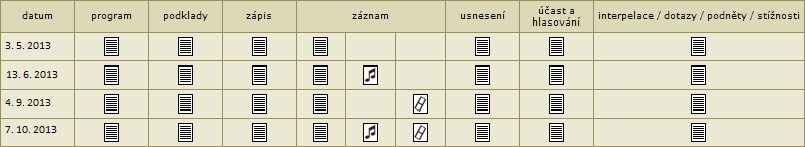

Asi nejpřehlednější jsou v tomto smyslu stránky zastupitelstva města [Černošice](http://www.mestocernosice.cz/mesto/mesto-cernosice/vedeni-mesta/zastupitelstvo-mesta/) – chybí zde nicméně informace o jmenovitém hlasování. Jiné obce zveřejňují také veliké množství informací, nicméně nikoliv na jednom místě, např. [Praha](http://www.praha.eu/jnp/cz/home/volene_organy/zastupitelstvo_hmp/index.html) nebo [Kuřim](http://www.kurim.cz/cs/samosprava/zastupitelstvo-mesta-zm/) (ta ovšem přestala zveřejňovat záznamy ze zasedání zastupitelstva)

#### Informace z výborů zastupitelstva, z rady a komisí rady

Zastupitelstvo je sice jediným občany přímo voleným orgánem a má také nejdůležitější rozhodovací pravomoci, avšak naprostá většina rozhodnutí bývá předjednána ve výborech zastupitelstva, respektive v radě a jejích komisích. Při projednávání na zastupitelstvu pak může být pouze uvedeno, že rada a příslušné výbory zastupitelstva doporučují nějaké usnesení ke schválení a o obsahu usnesení se již nejedná. Rada má navíc ještě samostatné rozhodovací kompetence, nezávisle na zastupitelstvu. Proto potřebují mít občané přístup k adekvátnímu množství informací a dokumentů také z jednání výborů zastupitelstva, rady a jejích komisí. Vzhledem k ze zákona neveřejné povaze zasedání rady a komisí se může zdát, že by snad mělo stačit zveřejnit zápis a usnesení. Takový přístup však neodpovídá za prvé důležitosti rozhodnutí, která jsou v těchto orgánech přijímána, a za druhé standardům transparentnosti moderního úřadu. Neveřejnost v tomto pojetí neznamená nic víc, než aby radní na zasedání nebyly nikým rušeni. Ostatně jsou obce, které neuzavírají veřejnosti ani zasedání rady a nejenže poskytují bohaté informace z jednání online, ale přímo jednání rady otevírají veřejnosti. Příkladem takové obce je výše zmiňovaná [Kuřim](http://www.kurim.cz/cs/samosprava/). Proto nevidíme žádnou překážku pro zveřejňování informací z těchto orgánů ekvivalentním způsobem, jakým jsme to výše stanovili pro zastupitelstvo.

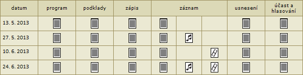

Pro snadnou práci s takovým množstvím informací je zcela nezbytný fulltextový vyhledávač, prohledávající všechny dokumenty v obou tabulkách.

[figure not shown]

| **Nenašli jste, co jste hledali?** **Napište našemu expertovi** **Markovi Zelenkovi na** **poradna@oziveni.cz** |
| --- |

## Související kauzy

#### [Finanční dar starostovi obce Hamr na Jezeře za zajištění kulturních akcí obce? Nezákonné, rozhodl soud](https://www.oziveni.cz/2022/07/financni-dar-starostovi-obce-hamr-na-jezere-za-zajisteni-kulturnich-akci-obce/)

[více »](https://www.oziveni.cz/2022/07/financni-dar-starostovi-obce-hamr-na-jezere-za-zajisteni-kulturnich-akci-obce/)

#### [Ústavní soud nám dal za pravdu](https://www.oziveni.cz/2022/05/ustavni-soud-nam-dal-za-pravdu/)

[více »](https://www.oziveni.cz/2022/05/ustavni-soud-nam-dal-za-pravdu/)

#### [Nekonečný infospor s Českými drahami o smlouvy k rozvoji lokality Masarykova nádraží (snad) půjde do finále.](https://www.oziveni.cz/2021/06/nekonecny-infospor-s-ceskymi-drahami-o-smlouvy-k-rozvoji-lokality-masarykova-nadrazi-snad-pujde-do-finale/)

[více »](https://www.oziveni.cz/2021/06/nekonecny-infospor-s-ceskymi-drahami-o-smlouvy-k-rozvoji-lokality-masarykova-nadrazi-snad-pujde-do-finale/)

# publikace k tématu

[figure not shown]

**[Správná radnice: Manuál transparentní samosprávy 2017](https://www.oziveni.cz/wp-content/uploads/2017/10/sr_web.pdf)**

Transparentnost je jedním z nejefektivnějších nástrojů v boji proti korupci. Dostatečně rozsáhlý, jednoduchý a rychlý přístup veřejnosti k informacím má příznivý vliv na důvěru občanů v demokratické instituce a na jejich ochotu podílet se na veřejném životě, což je v současnosti často diskutovaný společenský problém.Tato publikace je primárně určena zástupcům obcí, kteří hledají praktická doporučení pro otevírání radnic, volebním kandidátům a v neposlední řadě aktivním občanům, kteří se zajímají o činnost své radnice. Publikace odkazuje na související webové stránky věnované tématu [www.spravnaradnice.cz](http://www.spravnaradnice.cz/), kde čtenáři mohou najít především příklady dobré praxe ke všem oblastem.

[figure not shown]

[Přenosy, pořizování a zveřejňování audiovizuálních záznamů z jednání zastupitelstva obce či kraje](https://www.oziveni.cz/wp-content/uploads/2013/01/Zverej%C5%88ovani-audiovizualnich-zaznamu-z-jednani-zastupitelstva.pdf)

(platforma Bezkorupce, 2012) detailní rozbor současné situace na poli pořizování a zveřejňování videozáznamů jednání zastupitelstev. Materiál zohledňuje aktuální postoje a aktivity Úřadu pro ochranu osobních údajů v této věci a rozebírá detailně jednotlivé aspekty problematiky z pohledu různých subjektů (občan, obec), dotčených zákonů (ústava, občanský zákoník, zákon o ochraně osobních údajů, zákon o svobodném přístupu k informacím) a shrnuje, na co si musí dát pořizovatel pozor, aby se nedostal do konfliktu s ochranou osobních údajů. Další informace k problematice naleznate rovněž na **[speciální tematické stránce](https://www.oziveni.cz/videozaznamy/)**.

[figure not shown]

**[Mohu si legálně nahrát zasedání zastupitelstva?](https://www.oziveni.cz/wp-content/uploads/2010/01/PP_nahravani_zastupitelstva.pdf)**

(Oživení, 2008) starší jednoduchý manuál seznamující občany s jejich právy při pořizování audovizuálních záznamů jednání zastupitelstva a argumenty hovořící pro legálnost takového počinu.

[figure not shown]

**[Právo občana domáhat se neplatnosti smluv uzavřených obcí či krajem](https://www.oziveni.cz/wp-content/uploads/2011/06/Pravo-obcana-domahat-se-neplatnosti-smluv-uzavrenych-obci-ci-krajem.pdf)**

(Libor Dušek, 2011) Vítězná práce kategorie Ústavní právo IV. konference studentské věděcké odborné činnosti 2011 Právnické fakulty Univerzity Karlovy. Práce se věnuje problematice možnosti občana domáhat se u soudu neplatnosti smlouvy, o níž se domnívá, že ji samosprávní celek (obec nebo kraj) uzavřel v rozporu se zákonem. Vychází z konkrétních neúspěšných pokusů o takovouto žalobu, podrobuje konfrontaci jednotlivé přístupy výkladu tohoto práva a své názory dokládá na konkrétních výrocích soudů. Zabývá se i možností řešení současné situace změnou legislativy v rámci Strategie vlády v boji proti korupci na období 2011-2012 po vzoru nedávno přijatého slovenského zákona.

[figure not shown]

**[Osobní odpovědnost veřejných funkcionářů: realita nebo fikce?](https://www.oziveni.cz/wp-content/uploads/2011/08/Osobni_odpovednost_verejnych_funkcionaru.pdf)**

(Oživení 2010) Osobní odpovědnost je důležitým předpokladem každého kvalitního rozhodování, a proto bývá na správce majetku uvalena smluvně či přímo zákonem. Platí to alespoň pro soukromý majetek, ať už ve vlastnictví fyzických osob či obchodních společností. Při pohledu na nastavení odpovědnosti veřejných funkcionářů za rozhodování o veřejném majetku člověk spíše nabývá pocitu, že majitel (občan) svému správci bezmezně věří… Realita však ukazuje, že nakládání s veřejným majetkem není v České republice zdaleka takové, jaké by mělo být.

Podkladové materiály: [Grošpic, Pavel: Škoda způsobená územnímu celku a uplatňování nároku na její náhradu: právní rozbor](https://www.oziveni.cz/documents/pravni-rozbor-vymahatelnost-odpovednosti.pdf); [Prchal, Petr: Škoda způsobená územnímu samosprávnému celku a problematika spojená s jejím vymáháním: právní stanovisko](https://www.oziveni.cz/wp-content/uploads/2010/08/pravni-stanovisko-petr-prchal-14062010.pdf)

[figure not shown]

**[Osobní odpovědnost veřejných funkcionářů](https://www.oziveni.cz/wp-content/uploads/2010/01/analyza-odpovednosti-pokuty-uohs.pdf)**

(Oživení, 2009) Výzkum vymáhání osobní odpovědnosti veřejných funkcionářů za škody způsobené při zadávání veřejných zakázek. Výzkum zjišťuje, nakolik je v českých městech a obcích vymáhána osobní odpovědnost za pokuty udělené v souvislosti porušování zákona o veřejných zakázkách.

[figure not shown]

**Transparentní samospráva**

(Oživení 2006) Balíček 40 protikorupčních opatření a Manuál pro bezkonfliktní aplikaci nového správního řádu. Soubor 40 konkrétních opatření zvyšujících transparentnost rozhodování a hospodaření samospráv. Pomocník a průvodce občana nekonečnou spletí paragrafů.

Publikaci Vám na vyžádání pošleme. V případě zájmu nás kontaktujte.